# Espumas de Tajo

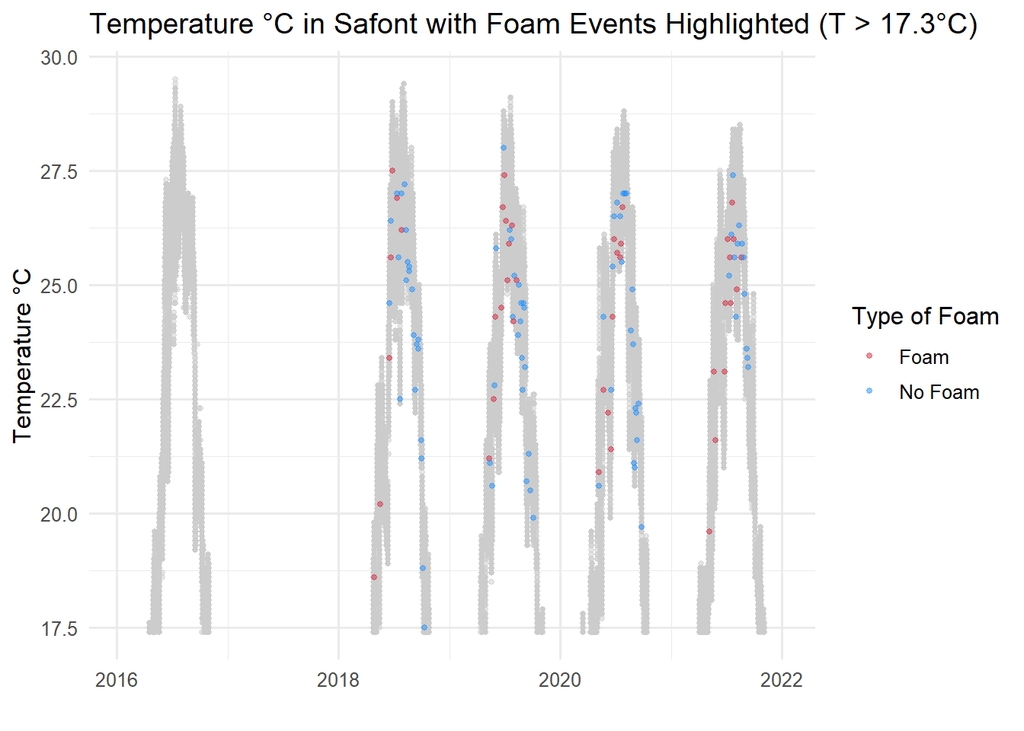

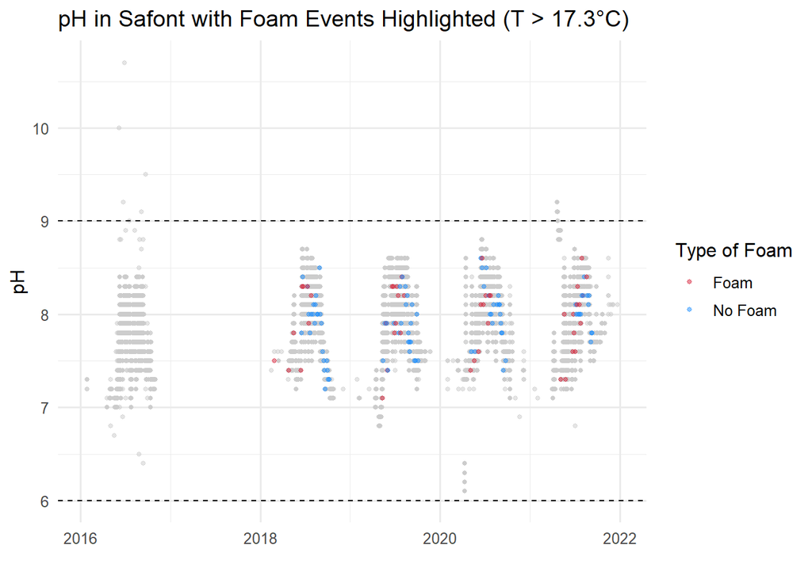

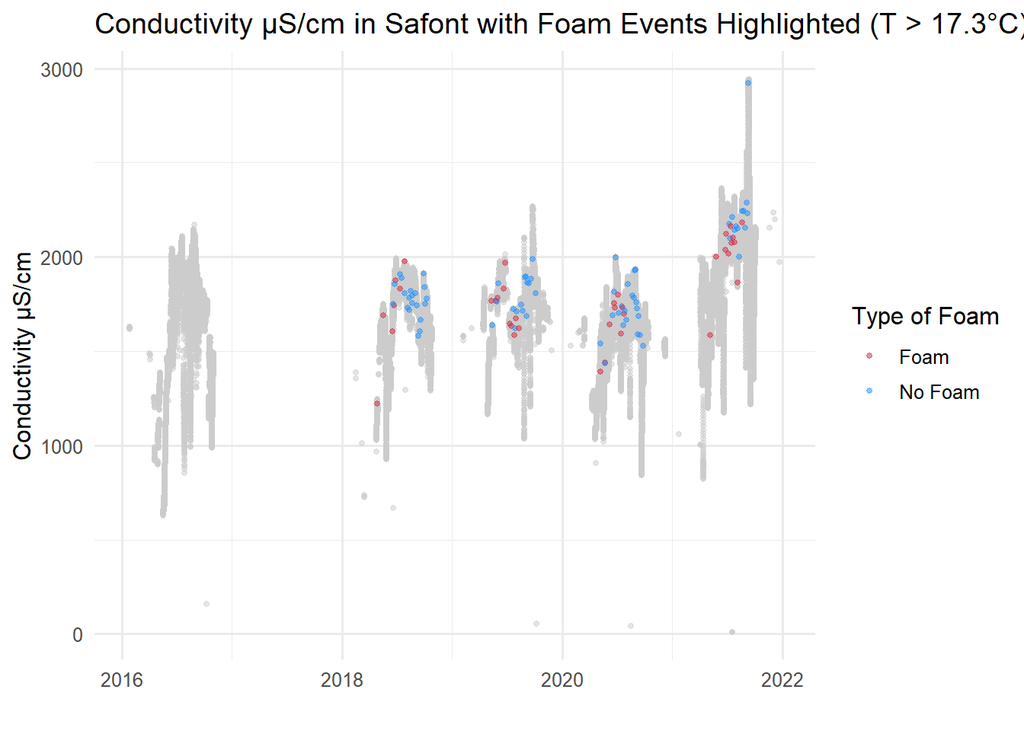

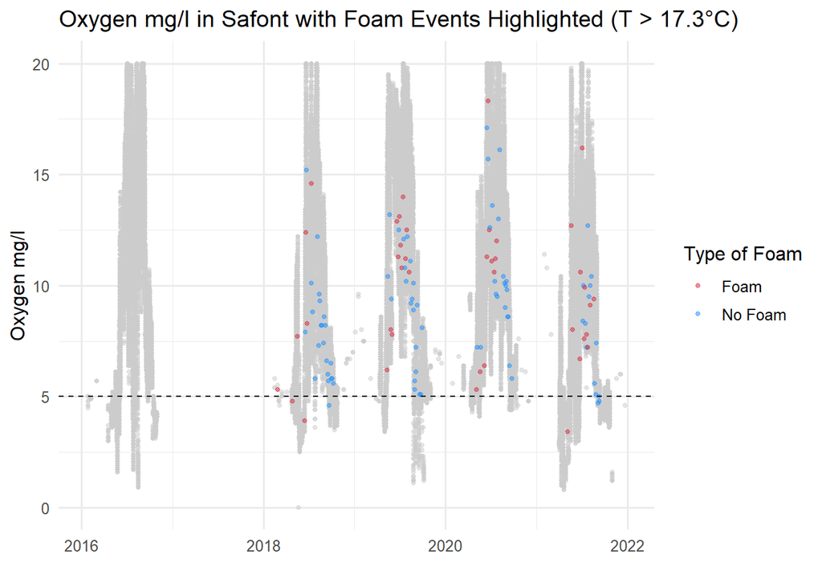

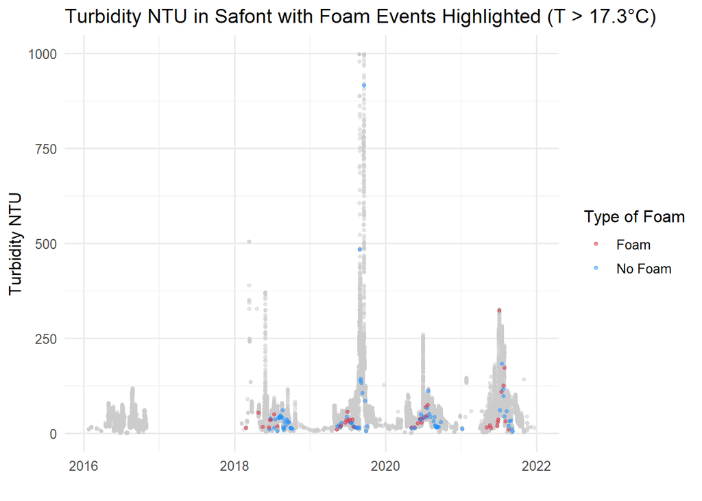

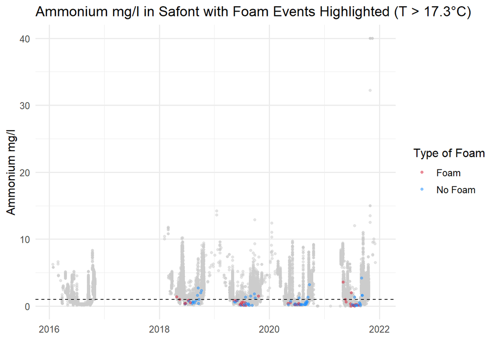

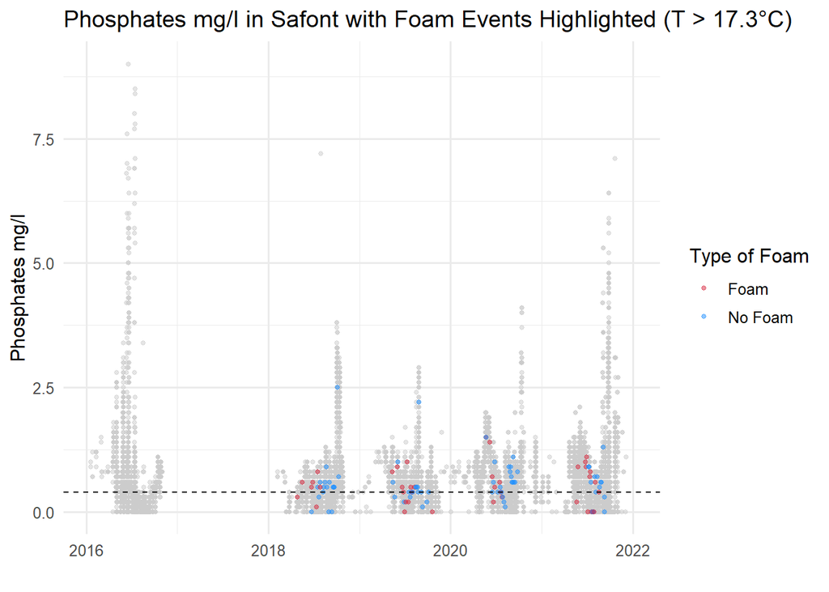

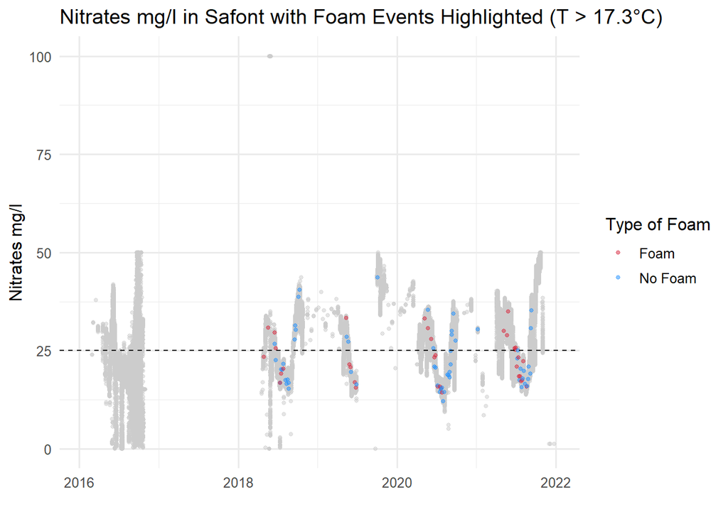

```r
# Combinar safont con data final
safont_highlighted = safont_caliente %>%
  left_join(final_caliente %>% select(Date, Foam), by = c("Date" = "Date")) %>%
  mutate(Espuma_cat = case_when(
    Foam == "Yes" ~ "Foam",
    Foam == "No" ~ "No Foam",
    TRUE ~ NA_character_
  ))

# Los gráficos
for (var in env_vars) {

  # Límite de nitratos
  if (var == "Nitrates mg/l") {
    safont_highlighted[[var]] = pmin(safont_highlighted[[var]], 100)
  }

  g = ggplot(safont_highlighted, aes(x = Date, y = .data[[var]])) +
    geom_point(data = safont_highlighted %>% filter(is.na(Espuma_cat)),
               color = "gray80", size = 1, alpha = 0.5) +
    geom_point(data = safont_highlighted %>% filter(!is.na(Espuma_cat)),
               aes(color = Espuma_cat), size = 1, alpha = 0.5) +
    scale_color_manual(values = c("Foam" = "#D7263D", "No Foam" = "#1E90FF")) +
    labs(title = paste(var, "in Safont with Foam Events Highlighted (T > 17.3°C)"), y = var, x = "", color = "Type of Foam") +
    theme_minimal(base_size = 12)

  if (!is.null(limits[[var]])) {
    if (!is.na(limits[[var]][1])) {
      g = g + geom_hline(yintercept = limits[[var]][1], linetype = "dashed", color = "black")
    }
    if (!is.na(limits[[var]][2])) {
      g = g + geom_hline(yintercept = limits[[var]][2], linetype = "dashed", color = "black")
    }
  }

  print(g)
}
```

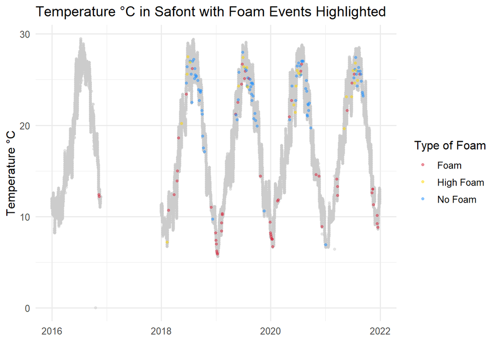

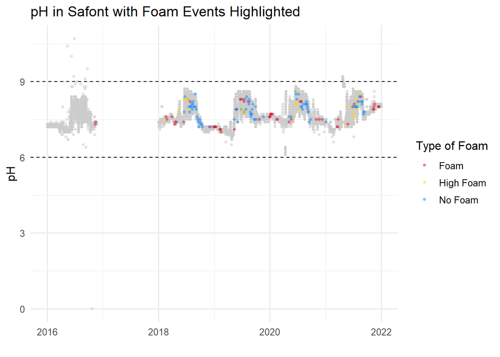

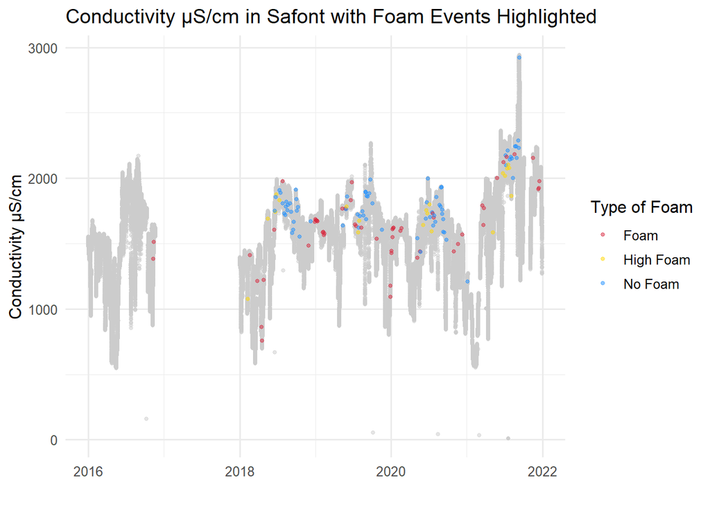

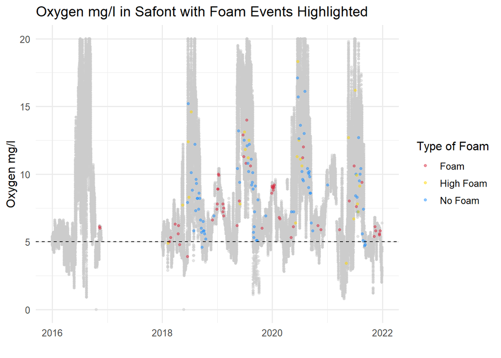

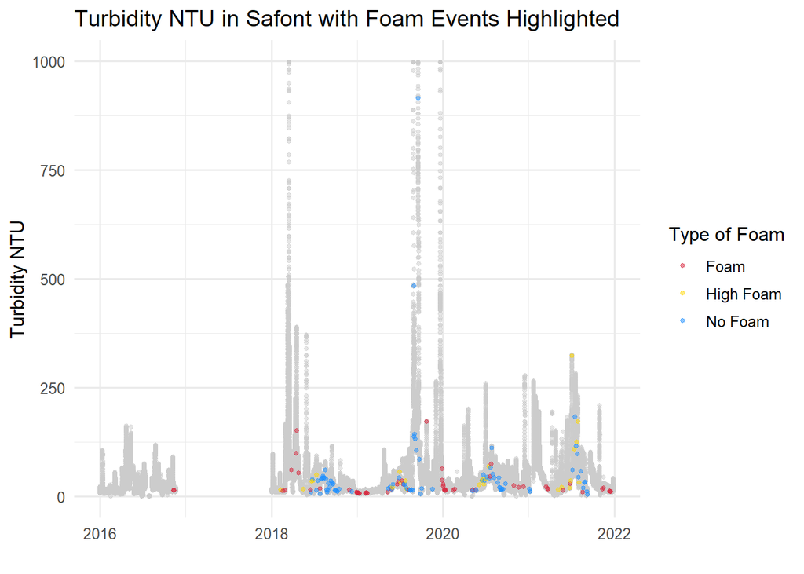

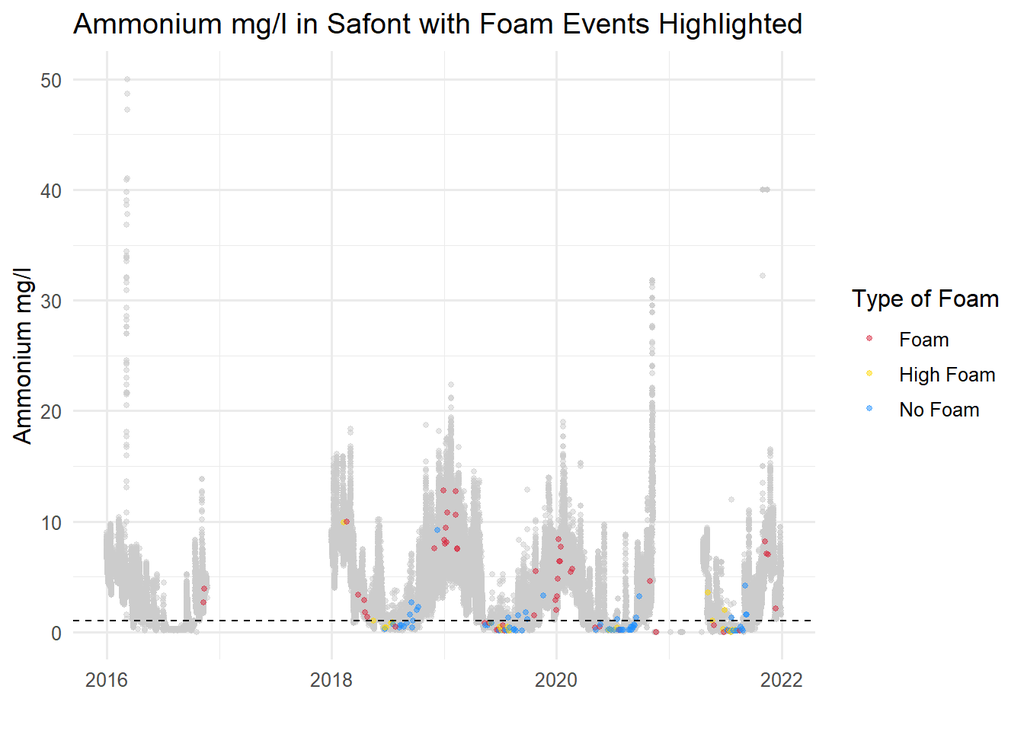

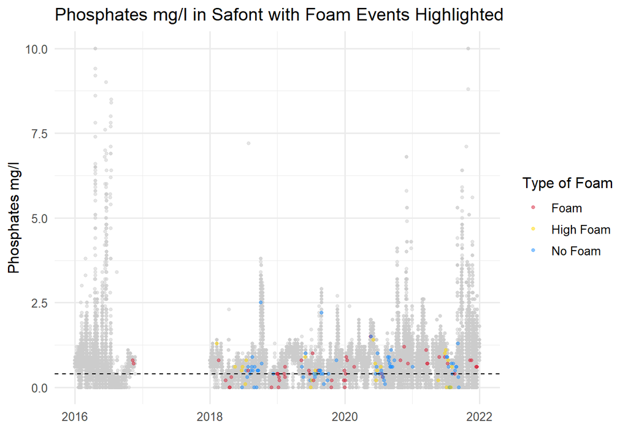

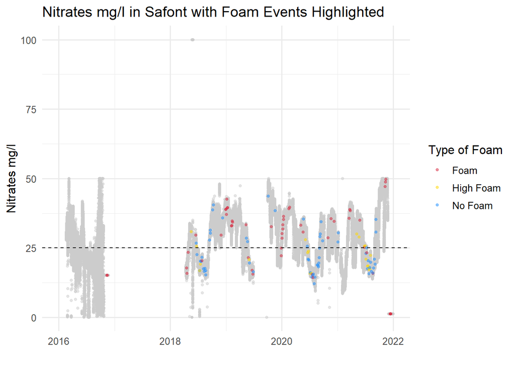

```r
# Combinar safont con data final
safont_highlighted = safont_2016 %>%
  left_join(final_data %>% select(Date, Foam, `High Foam`), by = c("Date" = "Date")) %>%
  mutate(Espuma_cat = case_when(
    `High Foam` == "Yes" ~ "High Foam",
    Foam == "Yes" ~ "Foam",
    Foam == "No" ~ "No Foam",
    TRUE ~ NA_character_
  ))

# Los gráficos
for (var in env_vars) {

  # Límite de nitratos
  if (var == "Nitrates mg/l") {
    safont_highlighted[[var]] = pmin(safont_highlighted[[var]], 100)
  }

  g = ggplot(safont_highlighted, aes(x = Date, y = .data[[var]])) +
    geom_point(data = safont_highlighted %>% filter(is.na(Espuma_cat)),
               color = "gray80", size = 1, alpha = 0.5) +
    geom_point(data = safont_highlighted %>% filter(!is.na(Espuma_cat)),
               aes(color = Espuma_cat), size = 1, alpha = 0.5) +
    scale_color_manual(values = c("Foam" = "#D7263D", "No Foam" = "#1E90FF", "High Foam" = "#FFD700")) +
    labs(title = paste(var, "in Safont with Foam Events Highlighted"), y = var, x = "", color = "Type of Foam") +
    theme_minimal(base_size = 12)

  if (!is.null(limits[[var]])) {
    if (!is.na(limits[[var]][1])) {
      g = g + geom_hline(yintercept = limits[[var]][1], linetype = "dashed", color = "black")
    }
    if (!is.na(limits[[var]][2])) {
      g = g + geom_hline(yintercept = limits[[var]][2], linetype = "dashed", color = "black")
    }
  }

  print(g)
}
```

## Mapa de Calor mensual

> Crear un mapa de calor mensual de la proporción de eventos de espuma

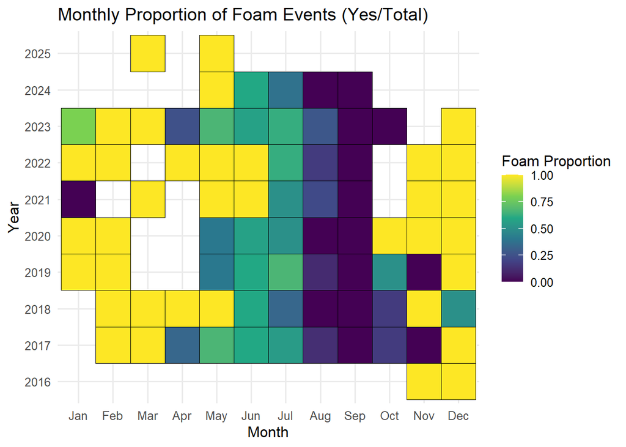

```r
# Crear columnas para mes y año
espuma_rate = comp_copernicus %>%
  filter(Foam %in% c("Yes", "No"))  %>%
  mutate(Year = year(Date),
         Month = month(Date, label = TRUE, abbr = TRUE)) %>%
  group_by(Year, Month) %>%
  summarize(
    Total = n(),
    Espuma_Si = sum(Foam == "Yes", na.rm = TRUE),
    Proporcion = Espuma_Si / Total,
    .groups = "drop"
  )

# Crear el mapa de calor
ggplot(espuma_rate, aes(x = Month, y = factor(Year), fill = Proporcion)) +
  geom_tile(color = "black") +
  scale_fill_viridis_c(name = "Foam Proportion", limits = c(0, 1)) +
  labs(title = "Monthly Proportion of Foam Events (Yes/Total)",
       x = "Month", y = "Year") +
  theme_minimal(base_size = 12)
```

> La proporción de días con espuma es claramente más alta en los meses fríos y lluviosos, lo que sugiere que factores como la escorrentía, el arrastre de nutrientes y materia orgánica, y las condiciones hidrológicas de invierno pueden favorecer su aparición. En cambio, los meses cálidos presentan menor proporción, posiblemente debido a menor escorrentía y mayor evaporación. Este patrón estacional debe considerarse al interpretar la calidad del agua y los procesos que afectan al Río Tajo en Toledo.

## Diagramas de Elipses

> Calcular y graficar correlaciones entre variables

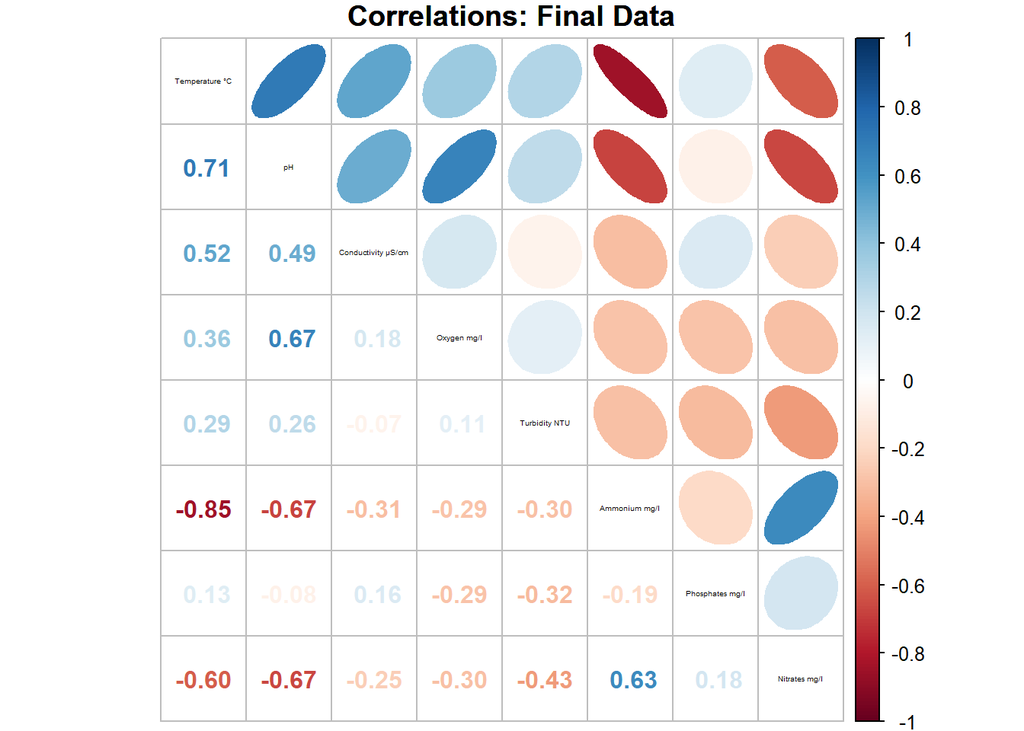

```r
#Final Data
cor_matrix_final = final_data %>% select(where(is.numeric)) %>% cor(use = "complete.obs")


corrplot.mixed(cor_matrix_final, upper = "ellipse",
  lower = "number",
  tl.col = "black",
  tl.cex = .3,
  number.cex = 1,
  mar = c(0, 0, 1, 0),
  main = "Correlations: Final Data")
```

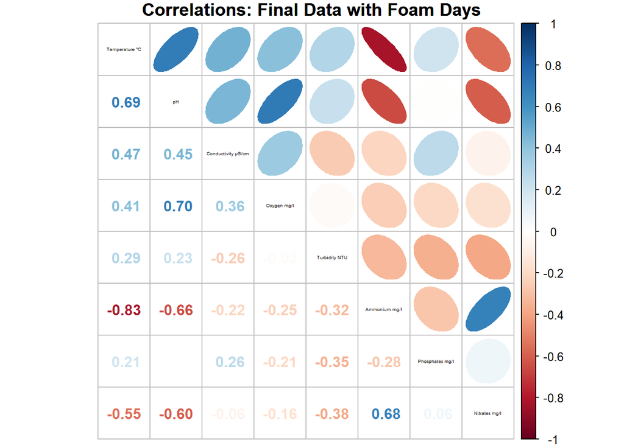

```r
#Final Data SI Espuma
cor_matrix_final = final_data %>% filter(Foam == "Yes") %>% select(where(is.numeric)) %>% cor(use = "complete.obs")


corrplot.mixed(cor_matrix_final, upper = "ellipse",
  lower = "number",
  tl.col = "black",
  tl.cex = .3,
  number.cex = 1,
  mar = c(0, 0, 1, 0),
  main = "Correlations: Final Data with Foam Days")
```

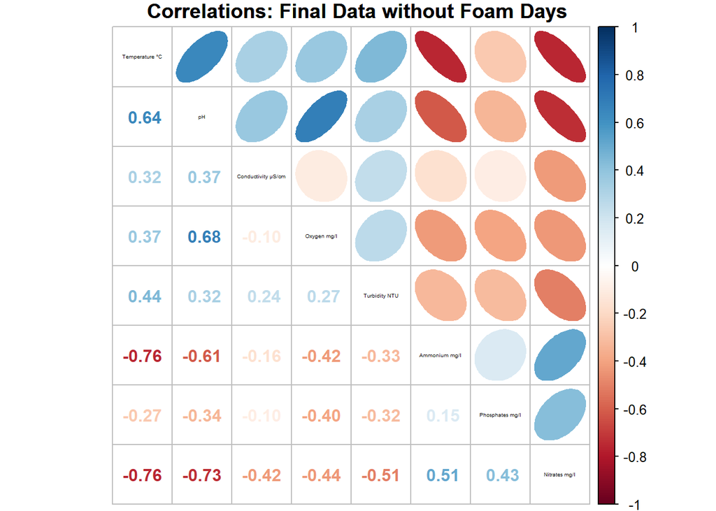

```r
#Final Data NO Espuma
cor_matrix_final = final_data %>% filter(Foam == "No") %>%  select(where(is.numeric)) %>% cor(use = "complete.obs")


corrplot.mixed(cor_matrix_final, upper = "ellipse",
  lower = "number",
  tl.col = "black",
  tl.cex = .3,
  number.cex = 1,
  mar = c(0, 0, 1, 0),
  main = "Correlations: Final Data without Foam Days")
```

[figure not shown]

```r
#Caliente Temp Final
cor_matrix_final_caliente = final_caliente %>% select(where(is.numeric)) %>% cor(use = "complete.obs")


corrplot.mixed(cor_matrix_final, upper = "ellipse",
  lower = "number",
  tl.col = "black",
  tl.cex = .3,
  number.cex = 1,
  mar = c(0, 0, 1, 0),
  main = "Correlations: Final Data (T > 17.3°C)")
```

[figure not shown]

```r
#Fría Temp Final
cor_matrix_final_fria = final_fria %>% select(where(is.numeric)) %>% cor(use = "complete.obs")
corrplot.mixed(cor_matrix_final, upper = "ellipse",
  lower = "number",
  tl.col = "black",
  tl.cex = .3,
  number.cex = 1,
  mar = c(0, 0, 1, 0), main = "Correlations: Final Data (T <= 17.3°C)")
```

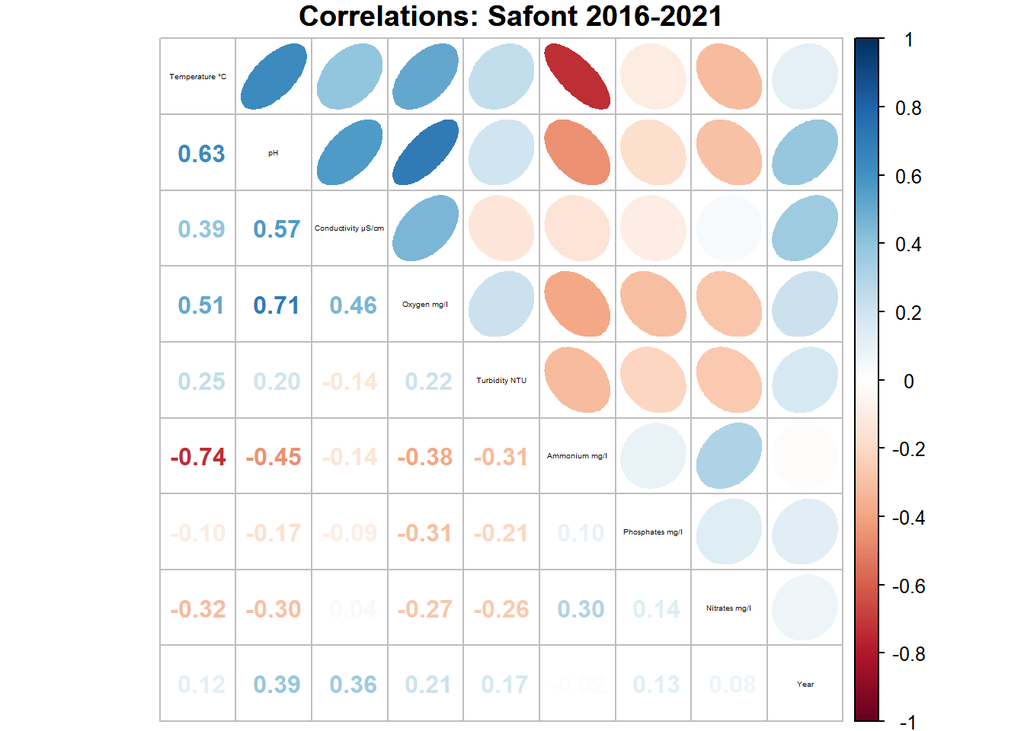

```r
#Safont 2016
cor_matrix_final = safont_2016 %>% select(where(is.numeric)) %>% cor(use = "complete.obs")


corrplot.mixed(cor_matrix_final, upper = "ellipse",
  lower = "number",
  tl.col = "black",
  tl.cex = .3,
  number.cex = 1,
  mar = c(0, 0, 1, 0), main = "Correlations: Safont 2016-2021")
```

[figure not shown]

```r
#Caliente Temp Safont 2016
cor_matrix_final_caliente = safont_caliente %>% select(where(is.numeric)) %>% cor(use = "complete.obs")


corrplot.mixed(cor_matrix_final, upper = "ellipse",
  lower = "number",
  tl.col = "black",
  tl.cex = .3,
  number.cex = 1,
  mar = c(0, 0, 1, 0),
  main = "Correlations: Safont 2016-2021 (T > 17.3°C)")
```

[figure not shown]

```r
#Fría Temp Safont 2016
cor_matrix_final_fria = safont_fria %>% select(where(is.numeric)) %>% cor(use = "complete.obs")


corrplot.mixed(cor_matrix_final,
  upper = "ellipse",
  lower = "number",
  tl.col = "black",
  tl.cex = .30,
  number.cex = 1,
  mar = c(0, 0, 1, 0),
  main = "Correlations: Safont 2016–2021 (T ≤ 17.3°C)")
```

> Temperatura y Amonio: Cuando la temperatura sube, los niveles de amonio bajan. Este sugiere que en temperaturas más altas, la actividad biológica aumenta. Bacterias nitrificantes convierten el amonio en nitratos más rapidamente en agua más caliente. También, en agua más caliente, la concentración de amonio suele disminuir debido al equilibrio entre amoníaco y amonio, formando más amoníaco que es un gas. Amoníaco no se disuelve bien en agua caliente, entonces, por lo general tiende a escaparse al aire. Por eso, cuando sube la temperatura, hay menos amonio en el agua. > pH y Amonio: Cuando el pH sube, el amonio baja. Este sugiere con un pH alto, el amonio se convierte en amoníaco, que es tóxico y tiende a salir del agua como gas. Eso baja su concentración. > pH y Oxígeno: Cuando el pH es más alto, hay más oxígeno. Esto podría indicar fotosíntesis acuática, como las algas y plantas liberan oxígeno y consumen CO2, lo que sube el pH. > Temperatura y pH: Cuando el agua está más fría, el pH tiende a ser más bajo. Este sugiere que en climas fríos, se reduce la fotosíntesis, lo que significa menos consumo de CO2 y por tanto más acidez, también es posible que la decomposición de materia orgánica puede liberar ácidos naturales al agua. > En cuanto a días con espuma y sin espuma, SI espuma muestran correlaciones más fuertes entre temperatura y variables como amonio y pH, lo que sugiere condiciones más frías, ácidas y contaminadas. En cambio, los días sin espuma mantienen estas relaciones, pero son un poco más débiles, indicando que estos facores están menos relacionados entre sí cuando no hay espuma.

## Prueba de las diferencias de medianas

> Función para pruebas de hipótesis sobre la mediana

```r
test_medianas = function(x, y, valor0 = 0, B = 1000, dependientes = FALSE){
  set.seed(123)
  # x: vector con los valores observados en la muestra 1
  # y: vector con los valores observados en la muestra 2
  # valor0: valor bajo H0 para diferencia de medianas
  # B: numero de remuestras en que está basado el test
  # dependientes: T/F value que informa si el test es para muestras dependientes. En

  est <- median(x) - median(y)
  est.b <- NULL
  if (dependientes){
    if(length(x) != length(y))
      stop("En muestras dependientes cada valor de x se relaciona con cada valor de y")
    for (ii in 1:B){
      muestra <- sample(1:length(x), size = length(x), replace = T)
      x.b <- x[muestra]
      y.b <- y[muestra]
      est.b <- c(est.b, median(x.b) - median(y.b))
    }
  } else {
    for (ii in 1:B){
      x.b <- sample(x, size = length(x), replace = T)
      y.b <- sample(y, size = length(y), replace = T)
      est.b <- c(est.b, median(x.b) - median(y.b))
    }
  }
  p.valor <- min(sum(est.b >= valor0), sum(est.b <= valor0))/B
  return(p.valor)
}

env_vars = final_data %>%
  select(where(is.numeric)) %>%
  colnames()

# Crear tabla para guardar resultados
resultados = data.frame(
  Variable = character(),
  Observed_Diff = numeric(),
  P_Value = numeric(),
  P_Value_Cold = numeric(),
  P_Value_Warm = numeric(),
  P_Value_Safont = numeric(),
  P_Value_Safont_Cold = numeric(),
  P_Value_Safont_Warm = numeric(),
  stringsAsFactors = FALSE
)

# Loop por cada variable numérica
for (var in env_vars) {

  df = final_data %>%
    filter(Foam %in% c("Yes", "No") & !is.na(.data[[var]]))

  df_fria = final_fria %>%
    filter(Foam %in% c("Yes", "No") & !is.na(.data[[var]]))

  df_caliente = final_caliente %>%
    filter(Foam %in% c("Yes", "No") & !is.na(.data[[var]]))

  df_safont = safont_2016 %>%
    filter(!is.na(.data[[var]]))

    x = df %>% filter(Foam == "Yes") %>% pull(.data[[var]])
    y = df %>% filter(Foam == "No") %>% pull(.data[[var]])

    x_fria = df_fria %>% filter(Foam == "Yes") %>% pull(.data[[var]])
    y_fria = df_fria %>% filter(Foam == "No") %>% pull(.data[[var]])

    x_caliente = df_caliente %>% filter(Foam == "Yes") %>% pull(.data[[var]])
    y_caliente = df_caliente %>% filter(Foam == "No") %>% pull(.data[[var]])

    y_safont = df_safont %>% pull(.data[[var]])

    #ALTA ESPUMA
    df_alta = final_data %>%
    filter(Foam %in% c("Yes", "No") & !is.na(.data[[var]])) %>% mutate(Foam = case_when(Foam == "Yes" & `High Foam` == "Yes" ~ "No", TRUE ~ NA_character_ ))

    x_alta = df_alta %>% filter(Foam == "Yes") %>% pull(.data[[var]])
    y_alta = df_alta %>% filter(Foam == "No") %>% pull(.data[[var]])


    # Llamar la funcion de prueba de medianas
    p_val = test_medianas(x, y)
    p_val_fria = test_medianas(x_fria, y_fria)
    p_val_caliente = test_medianas(x_caliente, y_caliente)
    p_val_safont = test_medianas(x, y_safont)
    p_val_alta = test_medianas(x_alta, y_alta)

    resultados = rbind(resultados, data.frame(
      Variable = var,
      P_Value_final = p_val,
      P_Value_Cold = p_val_fria,
      P_Value_Warm = p_val_caliente,
      P_Value_Safont = p_val_safont,
      P_Value_Alta = p_val_alta
    ))
  }

print(resultados)
```

```
##             Variable P_Value_final P_Value_Cold P_Value_Warm P_Value_Safont
## 1     Temperature °C         0.000        0.496        0.204          0.438
## 2                 pH         0.029        0.219        0.463          0.018
## 3 Conductivity µS/cm         0.001        0.454        0.228          0.010
## 4        Oxygen mg/l         0.149        0.434        0.162          0.000
## 5      Turbidity NTU         0.097        0.357        0.502          0.382
## 6      Ammonium mg/l         0.007        0.338        0.551          0.147
## 7    Phosphates mg/l         0.753        0.523        0.660          0.283
## 8      Nitrates mg/l         0.001        0.310        0.152          0.360
##   P_Value_Alta
## 1           NA
## 2           NA
## 3           NA
## 4           NA
## 5           NA
## 6           NA
## 7           NA
## 8           NA
```

> Los resultados muestran que en los días con espuma hay diferencias significativas en algunas variables del agua, como la temperatura, pH, conductividad, amonio y nitratos. Estas diferencias no se ven claramente cuando se analizan solo los días fríos o cálidos por separado, lo que sugiere que la espuma no depende solo de la temperatura.

## Estadisticas de Resumen

```r
print("Final Data")
```

```
## [1] "Final Data"
```

```r
summary(final_data)
```

```
##       Date                         Foam            High Foam
##  Min.   :2016-11-10 11:00:00   Length:178         Length:178
##  1st Qu.:2018-12-02 23:00:00   Class :character   Class :character
##  Median :2019-09-26 23:00:00   Mode  :character   Mode  :character
##  Mean   :2019-12-07 15:13:23
##  3rd Qu.:2020-09-14 04:45:00
##  Max.   :2021-12-17 11:00:00
##
##  Temperature °C        pH        Conductivity µS/cm  Oxygen mg/l
##  Min.   : 5.90   Min.   :7.000   Min.   : 756       Min.   : 3.400
##  1st Qu.:14.40   1st Qu.:7.500   1st Qu.:1606       1st Qu.: 6.200
##  Median :23.20   Median :7.900   Median :1732       Median : 8.400
##  Mean   :20.32   Mean   :7.813   Mean   :1743       Mean   : 8.669
##  3rd Qu.:25.60   3rd Qu.:8.100   3rd Qu.:1882       3rd Qu.:10.200
##  Max.   :28.00   Max.   :8.600   Max.   :2923       Max.   :18.300
##  NA's   :13      NA's   :5       NA's   :28         NA's   :17
##  Turbidity NTU    Ammonium mg/l    Phosphates mg/l  Nitrates mg/l
##  Min.   :  4.00   Min.   : 0.000   Min.   :0.0000   Min.   : 1.28
##  1st Qu.: 14.00   1st Qu.: 0.200   1st Qu.:0.3000   1st Qu.:17.68
##  Median : 21.00   Median : 0.600   Median :0.5000   Median :24.36
##  Mean   : 44.17   Mean   : 2.196   Mean   :0.5466   Mean   :25.40
##  3rd Qu.: 40.50   3rd Qu.: 2.800   3rd Qu.:0.7000   3rd Qu.:32.94
##  Max.   :915.00   Max.   :12.800   Max.   :2.5000   Max.   :49.73
##  NA's   :11       NA's   :39       NA's   :30       NA's   :46
##     Source
##  Length:178
##  Class :character
##  Mode  :character
##
##
##
##
```

```r
print("Final Data Cold")
```

```
## [1] "Final Data Cold"
```

```r
summary(final_fria)
```

```
##       Date                         Foam            High Foam
##  Min.   :2016-11-10 11:00:00   Length:46          Length:46
##  1st Qu.:2019-01-02 23:00:00   Class :character   Class :character
##  Median :2019-12-29 11:00:00   Mode  :character   Mode  :character
##  Mean   :2019-11-04 01:35:52
##  3rd Qu.:2020-12-04 11:00:00
##  Max.   :2021-12-17 11:00:00
##
##  Temperature °C        pH        Conductivity µS/cm  Oxygen mg/l
##  Min.   : 5.90   Min.   :7.000   Min.   : 756       Min.   : 4.900
##  1st Qu.: 7.85   1st Qu.:7.200   1st Qu.:1441       1st Qu.: 5.925
##  Median :10.15   Median :7.500   Median :1585       Median : 6.850
##  Mean   :10.31   Mean   :7.483   Mean   :1536       Mean   : 7.160
##  3rd Qu.:12.40   3rd Qu.:7.675   3rd Qu.:1668       3rd Qu.: 8.875
##  Max.   :17.10   Max.   :8.100   Max.   :2154       Max.   :10.000
##                                  NA's   :3          NA's   :4
##  Turbidity NTU    Ammonium mg/l   Phosphates mg/l Nitrates mg/l
##  Min.   :  7.00   Min.   : 0.00   Min.   :0.000   Min.   : 1.28
##  1st Qu.: 11.00   1st Qu.: 3.40   1st Qu.:0.275   1st Qu.:28.51
##  Median : 15.00   Median : 7.00   Median :0.600   Median :34.60
##  Mean   : 25.41   Mean   : 6.43   Mean   :0.525   Mean   :31.23
##  3rd Qu.: 21.25   3rd Qu.: 8.30   3rd Qu.:0.800   3rd Qu.:38.78
##  Max.   :171.00   Max.   :12.80   Max.   :1.300   Max.   :49.73
##  NA's   :2        NA's   :9       NA's   :6       NA's   :5
##     Source          Below_median
##  Length:46          Length:46
##  Class :character   Class :character
##  Mode  :character   Mode  :character
##
##
##
##
```

```r
print("Final Data Cold SI")
```

```
## [1] "Final Data Cold SI"
```

```r
summary(final_fria %>% filter(Foam == "Yes"))
```

```
##       Date                         Foam            High Foam
##  Min.   :2016-11-10 11:00:00   Length:42          Length:42
##  1st Qu.:2019-01-05 05:00:00   Class :character   Class :character
##  Median :2019-12-31 23:00:00   Mode  :character   Mode  :character
##  Mean   :2019-11-10 12:42:08
##  3rd Qu.:2020-12-04 11:00:00
##  Max.   :2021-12-17 11:00:00
##
##  Temperature °C        pH        Conductivity µS/cm  Oxygen mg/l
##  Min.   : 5.90   Min.   :7.000   Min.   : 756       Min.   : 4.900
##  1st Qu.: 7.85   1st Qu.:7.200   1st Qu.:1441       1st Qu.: 5.925
##  Median :10.15   Median :7.500   Median :1585       Median : 6.750
##  Mean   :10.24   Mean   :7.495   Mean   :1539       Mean   : 7.171
##  3rd Qu.:12.40   3rd Qu.:7.700   3rd Qu.:1670       3rd Qu.: 8.875
##  Max.   :15.00   Max.   :8.100   Max.   :2154       Max.   :10.000
##                                  NA's   :3          NA's   :4
##  Turbidity NTU    Ammonium mg/l   Phosphates mg/l  Nitrates mg/l
##  Min.   :  7.00   Min.   : 0.00   Min.   :0.0000   Min.   : 1.28
##  1st Qu.: 10.75   1st Qu.: 3.65   1st Qu.:0.2000   1st Qu.:28.55
##  Median : 14.50   Median : 7.00   Median :0.6000   Median :34.41
##  Mean   : 26.45   Mean   : 6.44   Mean   :0.5189   Mean   :31.03
##  3rd Qu.: 22.00   3rd Qu.: 8.25   3rd Qu.:0.8000   3rd Qu.:38.80
##  Max.   :171.00   Max.   :12.80   Max.   :1.3000   Max.   :49.73
##  NA's   :2        NA's   :7       NA's   :5        NA's   :4
##     Source          Below_median
##  Length:42          Length:42
##  Class :character   Class :character
##  Mode  :character   Mode  :character
##
##
##
##
```

```r
print("Final Data Cold NO")
```

```
## [1] "Final Data Cold NO"
```

```r
summary(final_fria %>% filter(Foam == "No"))
```

```
##       Date                         Foam            High Foam
##  Min.   :2018-10-16 11:00:00   Length:4           Length:4
##  1st Qu.:2018-11-26 17:00:00   Class :character   Class :character
##  Median :2019-05-30 23:00:00   Mode  :character   Mode  :character
##  Mean   :2019-08-28 05:00:00
##  3rd Qu.:2020-02-29 11:00:00
##  Max.   :2021-01-03 11:00:00
##
##  Temperature °C        pH       Conductivity µS/cm  Oxygen mg/l
##  Min.   : 6.90   Min.   :7.20   Min.   :1209       Min.   :5.200
##  1st Qu.: 9.00   1st Qu.:7.20   1st Qu.:1466       1st Qu.:6.475
##  Median :10.15   Median :7.30   Median :1578       Median :6.900
##  Mean   :11.07   Mean   :7.35   Mean   :1508       Mean   :7.050
##  3rd Qu.:12.22   3rd Qu.:7.45   3rd Qu.:1622       3rd Qu.:7.475
##  Max.   :17.10   Max.   :7.60   Max.   :1668       Max.   :9.200
##
##  Turbidity NTU   Ammonium mg/l   Phosphates mg/l Nitrates mg/l
##  Min.   :11.00   Min.   :3.300   Min.   :0.4     Min.   :27.14
##  1st Qu.:14.75   1st Qu.:4.775   1st Qu.:0.5     1st Qu.:31.50
##  Median :16.00   Median :6.250   Median :0.6     Median :35.86
##  Mean   :15.00   Mean   :6.250   Mean   :0.6     Mean   :33.79
##  3rd Qu.:16.25   3rd Qu.:7.725   3rd Qu.:0.7     3rd Qu.:37.11
##  Max.   :17.00   Max.   :9.200   Max.   :0.8     Max.   :38.36
##                  NA's   :2       NA's   :1       NA's   :1
##     Source          Below_median
##  Length:4           Length:4
##  Class :character   Class :character
##  Mode  :character   Mode  :character
##
##
##
##
```

```r
print("Final Data Warm")
```

```
## [1] "Final Data Warm"
```

```r
summary(final_caliente)
```

```
##       Date                         Foam            High Foam
##  Min.   :2018-02-26 11:00:00   Length:132         Length:132
##  1st Qu.:2018-09-30 22:48:45   Class :character   Class :character
##  Median :2019-09-08 22:45:00   Mode  :character   Mode  :character
##  Mean   :2019-12-19 07:58:17
##  3rd Qu.:2020-09-06 04:48:45
##  Max.   :2021-09-10 10:45:00
##
##  Temperature °C        pH        Conductivity µS/cm  Oxygen mg/l
##  Min.   :17.50   Min.   :7.100   Min.   :1223       Min.   : 3.400
##  1st Qu.:22.70   1st Qu.:7.700   1st Qu.:1690       1st Qu.: 6.950
##  Median :24.60   Median :8.000   Median :1781       Median : 9.100
##  Mean   :24.19   Mean   :7.932   Mean   :1827       Mean   : 9.202
##  3rd Qu.:25.90   3rd Qu.:8.200   3rd Qu.:1931       3rd Qu.:11.100
##  Max.   :28.00   Max.   :8.600   Max.   :2923       Max.   :18.300
##  NA's   :13      NA's   :5       NA's   :25         NA's   :13
##  Turbidity NTU    Ammonium mg/l    Phosphates mg/l  Nitrates mg/l
##  Min.   :  4.00   Min.   :0.0000   Min.   :0.0000   Min.   :12.14
##  1st Qu.: 15.50   1st Qu.:0.2000   1st Qu.:0.3000   1st Qu.:17.30
##  Median : 29.00   Median :0.4000   Median :0.5000   Median :20.87
##  Mean   : 50.88   Mean   :0.6608   Mean   :0.5546   Mean   :22.78
##  3rd Qu.: 43.00   3rd Qu.:0.8000   3rd Qu.:0.7000   3rd Qu.:27.69
##  Max.   :915.00   Max.   :4.2000   Max.   :2.5000   Max.   :43.70
##  NA's   :9        NA's   :30       NA's   :24       NA's   :41
##     Source          Below_median
##  Length:132         Length:132
##  Class :character   Class :character
##  Mode  :character   Mode  :character
##
##
##
##
```

```r
print("Final Data Warm SI")
```

```
## [1] "Final Data Warm SI"
```

```r
summary(final_caliente %>% filter(Foam == "Yes"))
```

```
##       Date                         Foam            High Foam
##  Min.   :2018-02-26 11:00:00   Length:46          Length:46
##  1st Qu.:2019-06-06 11:00:00   Class :character   Class :character
##  Median :2020-05-13 23:00:00   Mode  :character   Mode  :character
##  Mean   :2020-02-13 13:04:33
##  3rd Qu.:2021-05-25 05:00:00
##  Max.   :2021-08-19 11:00:00
##
##  Temperature °C        pH        Conductivity µS/cm  Oxygen mg/l
##  Min.   :18.60   Min.   :7.100   Min.   :1223       Min.   : 3.400
##  1st Qu.:23.10   1st Qu.:7.600   1st Qu.:1642       1st Qu.: 7.600
##  Median :25.10   Median :8.000   Median :1766       Median :10.600
##  Mean   :24.41   Mean   :7.949   Mean   :1789       Mean   : 9.771
##  3rd Qu.:26.00   3rd Qu.:8.200   3rd Qu.:1976       3rd Qu.:12.000
##  Max.   :27.50   Max.   :8.600   Max.   :2182       Max.   :18.300
##  NA's   :5       NA's   :1       NA's   :9          NA's   :5
##  Turbidity NTU    Ammonium mg/l    Phosphates mg/l Nitrates mg/l
##  Min.   :  9.00   Min.   :0.0000   Min.   :0.000   Min.   :14.31
##  1st Qu.: 17.00   1st Qu.:0.2000   1st Qu.:0.200   1st Qu.:17.34
##  Median : 30.50   Median :0.4000   Median :0.500   Median :22.24
##  Mean   : 44.00   Mean   :0.5692   Mean   :0.525   Mean   :22.81
##  3rd Qu.: 39.75   3rd Qu.:0.8000   3rd Qu.:0.800   3rd Qu.:26.87
##  Max.   :323.00   Max.   :3.6000   Max.   :1.500   Max.   :35.00
##  NA's   :4        NA's   :7        NA's   :6       NA's   :11
##     Source          Below_median
##  Length:46          Length:46
##  Class :character   Class :character
##  Mode  :character   Mode  :character
##
##
##
##
```

```r
print("Final Data Warm NO")
```

```
## [1] "Final Data Warm NO"
```

```r
summary(final_caliente %>% filter(Foam == "No"))
```

```
##       Date                         Foam            High Foam
##  Min.   :2018-06-18 10:45:00   Length:86          Length:86
##  1st Qu.:2018-09-19 22:56:15   Class :character   Class :character
##  Median :2019-09-02 22:52:30   Mode  :character   Mode  :character
##  Mean   :2019-11-19 06:21:27
##  3rd Qu.:2020-08-30 22:48:45
##  Max.   :2021-09-10 10:45:00
##
##  Temperature °C        pH        Conductivity µS/cm  Oxygen mg/l
##  Min.   :17.50   Min.   :7.200   Min.   :1436       Min.   : 4.600
##  1st Qu.:22.70   1st Qu.:7.700   1st Qu.:1713       1st Qu.: 6.525
##  Median :24.40   Median :8.000   Median :1794       Median : 8.850
##  Mean   :24.07   Mean   :7.923   Mean   :1846       Mean   : 8.903
##  3rd Qu.:25.75   3rd Qu.:8.100   3rd Qu.:1910       3rd Qu.:10.200
##  Max.   :28.00   Max.   :8.600   Max.   :2923       Max.   :17.100
##  NA's   :8       NA's   :4       NA's   :16         NA's   :8
##  Turbidity NTU    Ammonium mg/l    Phosphates mg/l  Nitrates mg/l
##  Min.   :  4.00   Min.   :0.1000   Min.   :0.0000   Min.   :12.14
##  1st Qu.: 15.00   1st Qu.:0.2000   1st Qu.:0.4000   1st Qu.:17.27
##  Median : 29.00   Median :0.4000   Median :0.5000   Median :20.27
##  Mean   : 54.44   Mean   :0.7175   Mean   :0.5721   Mean   :22.76
##  3rd Qu.: 43.00   3rd Qu.:0.9000   3rd Qu.:0.7000   3rd Qu.:27.62
##  Max.   :915.00   Max.   :4.2000   Max.   :2.5000   Max.   :43.70
##  NA's   :5        NA's   :23       NA's   :18       NA's   :30
##     Source          Below_median
##  Length:86          Length:86
##  Class :character   Class :character
##  Mode  :character   Mode  :character
##
##
##
##
```

```r
print("Safont Data 2016")
```

```
## [1] "Safont Data 2016"
```

```r
summary(safont_2016)
```

```
##  station_name            Date                     Temperature °C
##  Length:161849      Min.   :2016-01-01 00:00:00   Min.   : 0.00
##  Class :character   1st Qu.:2018-04-22 18:45:00   1st Qu.:12.00
##  Mode  :character   Median :2019-07-14 06:15:00   Median :17.30
##                     Mean   :2019-05-03 12:19:16   Mean   :17.79
##                     3rd Qu.:2020-09-30 21:45:00   3rd Qu.:23.90
##                     Max.   :2021-12-31 23:45:00   Max.   :29.50
##                                                   NA's   :5650
##        pH         Conductivity µS/cm  Oxygen mg/l     Turbidity NTU
##  Min.   : 0.000   Min.   :  10       Min.   : 0.000   Min.   :  0.00
##  1st Qu.: 7.300   1st Qu.:1400       1st Qu.: 5.300   1st Qu.: 14.00
##  Median : 7.500   Median :1601       Median : 6.400   Median : 20.00
##  Mean   : 7.607   Mean   :1562       Mean   : 7.796   Mean   : 36.59
##  3rd Qu.: 7.900   3rd Qu.:1760       3rd Qu.: 9.500   3rd Qu.: 40.00
##  Max.   :10.700   Max.   :2943       Max.   :20.000   Max.   :998.00
##  NA's   :5570     NA's   :20045      NA's   :13916    NA's   :16163
##  Ammonium mg/l    Phosphates mg/l   Nitrates mg/l         Year
##  Min.   : 0.000   Min.   : 0.0000   Min.   :  0.00   Min.   :2016
##  1st Qu.: 0.500   1st Qu.: 0.3000   1st Qu.: 19.07   1st Qu.:2018
##  Median : 2.200   Median : 0.6000   Median : 27.90   Median :2019
##  Mean   : 3.209   Mean   : 0.6229   Mean   : 27.76   Mean   :2019
##  3rd Qu.: 5.200   3rd Qu.: 0.8000   3rd Qu.: 35.13   3rd Qu.:2020
##  Max.   :50.000   Max.   :10.0000   Max.   :331.50   Max.   :2021
##  NA's   :32194    NA's   :20589     NA's   :35195
```

```r
print("Safont Data Cold")
```

```
## [1] "Safont Data Cold"
```

```r
summary(safont_fria)
```

```
##  station_name            Date                     Temperature °C
##  Length:78321       Min.   :2016-01-01 00:00:00   Min.   : 0.00
##  Class :character   1st Qu.:2018-03-02 03:30:00   1st Qu.:10.20
##  Mode  :character   Median :2019-03-31 09:15:00   Median :12.00
##                     Mean   :2019-03-31 11:19:08   Mean   :12.24
##                     3rd Qu.:2020-10-29 19:15:00   3rd Qu.:14.60
##                     Max.   :2021-12-31 04:45:00   Max.   :17.30
##
##        pH         Conductivity µS/cm  Oxygen mg/l     Turbidity NTU
##  Min.   : 0.000   Min.   :  35       Min.   : 0.000   Min.   :  0.00
##  1st Qu.: 7.200   1st Qu.:1295       1st Qu.: 5.200   1st Qu.: 12.00
##  Median : 7.400   Median :1501       Median : 5.900   Median : 17.00
##  Mean   : 7.389   Mean   :1425       Mean   : 6.178   Mean   : 34.12
##  3rd Qu.: 7.500   3rd Qu.:1618       3rd Qu.: 6.800   3rd Qu.: 33.00
##  Max.   :10.400   Max.   :2238       Max.   :11.400   Max.   :998.00
##  NA's   :634      NA's   :3780       NA's   :2769     NA's   :3426
##  Ammonium mg/l    Phosphates mg/l   Nitrates mg/l        Year
##  Min.   : 0.000   Min.   : 0.0000   Min.   : 0.00   Min.   :2016
##  1st Qu.: 3.300   1st Qu.: 0.4000   1st Qu.:24.08   1st Qu.:2018
##  Median : 5.100   Median : 0.8000   Median :33.21   Median :2019
##  Mean   : 5.407   Mean   : 0.7019   Mean   :29.78   Mean   :2019
##  3rd Qu.: 7.200   3rd Qu.: 0.9000   3rd Qu.:37.03   3rd Qu.:2020
##  Max.   :50.000   Max.   :10.0000   Max.   :50.00   Max.   :2021
##  NA's   :16650    NA's   :9369      NA's   :18593
##  Below_median
##  Length:78321
##  Class :character
##  Mode  :character
##
##
##
##
```

```r
print("Safont Data Warm")
```

```
## [1] "Safont Data Warm"
```

```r
summary(safont_caliente)
```

```
##  station_name            Date                     Temperature °C
##  Length:83528       Min.   :2016-01-18 10:45:00   Min.   :17.40
##  Class :character   1st Qu.:2018-06-25 08:56:15   1st Qu.:20.80
##  Mode  :character   Median :2019-08-05 20:07:30   Median :23.90
##                     Mean   :2019-06-03 11:53:21   Mean   :23.37
##                     3rd Qu.:2020-09-10 20:33:45   3rd Qu.:26.10
##                     Max.   :2021-12-31 23:45:00   Max.   :29.50
##                                                   NA's   :5650
##        pH         Conductivity µS/cm  Oxygen mg/l     Turbidity NTU
##  Min.   : 6.100   Min.   :  10       Min.   : 0.000   Min.   :  0.00
##  1st Qu.: 7.500   1st Qu.:1574       1st Qu.: 5.500   1st Qu.: 16.00
##  Median : 7.800   Median :1737       Median : 8.900   Median : 29.00
##  Mean   : 7.823   Mean   :1715       Mean   : 9.485   Mean   : 39.21
##  3rd Qu.: 8.200   3rd Qu.:1876       3rd Qu.:12.800   3rd Qu.: 42.00
##  Max.   :10.700   Max.   :2943       Max.   :20.000   Max.   :998.00
##  NA's   :4936     NA's   :16265      NA's   :11147    NA's   :12737
##  Ammonium mg/l    Phosphates mg/l  Nitrates mg/l         Year
##  Min.   : 0.000   Min.   :0.0000   Min.   :  0.00   Min.   :2016
##  1st Qu.: 0.200   1st Qu.:0.3000   1st Qu.: 18.06   1st Qu.:2018
##  Median : 0.600   Median :0.5000   Median : 23.36   Median :2019
##  Mean   : 1.215   Mean   :0.5475   Mean   : 25.95   Mean   :2019
##  3rd Qu.: 1.500   3rd Qu.:0.7000   3rd Qu.: 30.94   3rd Qu.:2020
##  Max.   :40.000   Max.   :9.0000   Max.   :331.50   Max.   :2021
##  NA's   :15544    NA's   :11220    NA's   :16602
##  Below_median
##  Length:83528
##  Class :character
##  Mode  :character
##
##
##
##
```

```r
print("Final Data SI")
```

```
## [1] "Final Data SI"
```

```r
summary(final_data %>% filter(Foam == "Yes"))
```

```
##       Date                         Foam            High Foam
##  Min.   :2016-11-10 11:00:00   Length:88          Length:88
##  1st Qu.:2019-01-11 17:00:00   Class :character   Class :character
##  Median :2020-01-03 11:00:00   Mode  :character   Mode  :character
##  Mean   :2019-12-30 04:42:57
##  3rd Qu.:2021-03-22 22:56:15
##  Max.   :2021-12-17 11:00:00
##
##  Temperature °C        pH       Conductivity µS/cm  Oxygen mg/l
##  Min.   : 5.90   Min.   :7.00   Min.   : 756       Min.   : 3.40
##  1st Qu.:10.15   1st Qu.:7.40   1st Qu.:1561       1st Qu.: 6.15
##  Median :15.00   Median :7.70   Median :1656       Median : 7.80
##  Mean   :17.24   Mean   :7.73   Mean   :1661       Mean   : 8.52
##  3rd Qu.:25.00   3rd Qu.:8.10   3rd Qu.:1805       3rd Qu.:10.60
##  Max.   :27.50   Max.   :8.60   Max.   :2182       Max.   :18.30
##  NA's   :5       NA's   :1      NA's   :12         NA's   :9
##  Turbidity NTU    Ammonium mg/l    Phosphates mg/l  Nitrates mg/l
##  Min.   :  7.00   Min.   : 0.000   Min.   :0.0000   Min.   : 1.28
##  1st Qu.: 13.25   1st Qu.: 0.325   1st Qu.:0.2000   1st Qu.:18.50
##  Median : 19.00   Median : 1.450   Median :0.5000   Median :28.51
##  Mean   : 35.44   Mean   : 3.346   Mean   :0.5221   Mean   :27.09
##  3rd Qu.: 35.00   3rd Qu.: 6.400   3rd Qu.:0.8000   3rd Qu.:34.67
##  Max.   :323.00   Max.   :12.800   Max.   :1.5000   Max.   :49.73
##  NA's   :6        NA's   :14       NA's   :11       NA's   :15
##     Source
##  Length:88
##  Class :character
##  Mode  :character
##
##
##
##
```

```r
print("Final Data NO")
```

```
## [1] "Final Data NO"
```

```r
summary(final_data %>% filter(Foam == "No"))
```

```
##       Date                         Foam            High Foam
##  Min.   :2018-06-18 10:45:00   Length:90          Length:90
##  1st Qu.:2018-09-23 10:48:45   Class :character   Class :character
##  Median :2019-09-02 22:52:30   Mode  :character   Mode  :character
##  Mean   :2019-11-15 13:45:50
##  3rd Qu.:2020-08-30 22:48:45
##  Max.   :2021-09-10 10:45:00
##
##  Temperature °C        pH        Conductivity µS/cm  Oxygen mg/l
##  Min.   : 6.90   Min.   :7.200   Min.   :1209       Min.   : 4.600
##  1st Qu.:22.32   1st Qu.:7.625   1st Qu.:1692       1st Qu.: 6.525
##  Median :24.30   Median :7.950   Median :1782       Median : 8.700
##  Mean   :23.44   Mean   :7.897   Mean   :1828       Mean   : 8.812
##  3rd Qu.:25.60   3rd Qu.:8.100   3rd Qu.:1904       3rd Qu.:10.175
##  Max.   :28.00   Max.   :8.600   Max.   :2923       Max.   :17.100
##  NA's   :8       NA's   :4       NA's   :16         NA's   :8
##  Turbidity NTU    Ammonium mg/l    Phosphates mg/l  Nitrates mg/l
##  Min.   :  4.00   Min.   :0.1000   Min.   :0.0000   Min.   :12.14
##  1st Qu.: 15.00   1st Qu.:0.2000   1st Qu.:0.4000   1st Qu.:17.50
##  Median : 28.00   Median :0.4000   Median :0.5000   Median :20.71
##  Mean   : 52.59   Mean   :0.8877   Mean   :0.5732   Mean   :23.32
##  3rd Qu.: 43.00   3rd Qu.:1.2000   3rd Qu.:0.7000   3rd Qu.:28.12
##  Max.   :915.00   Max.   :9.2000   Max.   :2.5000   Max.   :43.70
##  NA's   :5        NA's   :25       NA's   :19       NA's   :31
##     Source
##  Length:90
##  Class :character
##  Mode  :character
##
##
##
##
```

> Final Data Temperatura: media 20.32 °C, mediana 23.20 °C Amonio: media 2.196 mg/l, mediana 0.6 mg/l Fosfatos: media 0.5466 mg/l, mediana 0.5 mg/l Nitratos: media 25.40 mg/l, mediana 24.36 mg/l pH: media 7.813, mediana 7.9

> Final Data Cold Temperatura: media 10.31 °C, mediana 10.15 °C Amonio: media 6.43 mg/l, mediana 7.0 mg/l Fosfatos: media 0.525 mg/l, mediana 0.6 mg/l Nitratos: media 31.23 mg/l, mediana 34.6 mg/l pH: media 7.483, mediana 7.5

> Final Data Warm Temperatura: media 24.19°C, mediana 24.60 °C Amonio: media 0.6608 mg/l, mediana 0.4 mg/l Fosfatos: media 0.5546 mg/l, mediana 0.5 mg/l Nitratos: media 22.78 mg/l, mediana 20.87 mg/l pH: media 7.932, mediana 8.0

> Safont Data Temperatura: media 17.79 °C, mediana 17.30 °C Amonio: media 3.209 mg/l, mediana 2.2 mg/l Fosfatos: media 0.6229 mg/l, mediana 0.6 mg/l Nitratos: media 27.76 mg/l, mediana 27.90 mg/l pH: media 7.607, mediana 7.5

## Conjuntos de datos con caudales

```r
caudales = read_excel("caudales_final.xlsx", sheet = "Tajo en Algodor")
caudales = caudales %>% mutate(Day = dmy(DÍA)) %>% select(-DÍA) %>% select(Day, CAUDAL, ALTURA)
comp_copernicus_date = comp_copernicus %>% mutate(Day = dmy(Day))
copernicus_caudales = left_join(comp_copernicus_date, caudales, by = "Day")
copernicus_caudales = copernicus_caudales %>% select(-Time, -Source, -Date)
copernicus_caudales = copernicus_caudales %>% filter(!is.na(CAUDAL))

final_caudales = final_data %>% mutate(Day = as.Date(Date))
final_caudales = final_caudales %>% left_join(caudales, by = "Day")
#Cold
final_caudales_cold = final_fria %>% mutate(Day = as.Date(Date))
final_caudales_cold = final_caudales_cold %>% left_join(caudales, by = "Day")
#Warm
final_caudales_warm = final_caliente %>% mutate(Day = as.Date(Date))
final_caudales_warm = final_caudales_warm %>% left_join(caudales, by = "Day")

final_caudales_warm = final_caudales_warm %>% select(-Date)
final_caudales_cold = final_caudales_cold %>% select(-Date)
final_caudales = final_caudales %>% select(-Date)
```

## Percentiles y Regresión con caudales

```r
copernicus_caudales = copernicus_caudales %>% mutate(Year = year(Day), Month = month(Day, label = TRUE, abbr = FALSE)) %>% filter(Year >= 2016 & Year <= 2021)

copernicus_caudales_cold = final_caudales_cold %>% mutate(Year = year(Day), Month = month(Day, label = TRUE, abbr = FALSE)) %>% filter(Year >= 2016 & Year <= 2021)

copernicus_caudales_warm = final_caudales_warm %>% mutate(Year = year(Day), Month = month(Day, label = TRUE, abbr = FALSE)) %>% filter(Year >= 2016 & Year <= 2021)

get_percentile = function(value, vector){
  ecdf(vector)(value) * 100
}

copernicus_caudales = copernicus_caudales %>% filter(!is.na(CAUDAL)) %>% group_by(Month) %>% mutate(Caudal_perc_month = ifelse(!is.na(CAUDAL), get_percentile(CAUDAL, CAUDAL), NA)) %>% ungroup()

reg_caudales = copernicus_caudales %>% filter(!is.na(Foam)) %>% mutate(Binary_Foam = ifelse(Foam == "Yes", 1, 0))
final_caudales_cold = final_caudales_cold %>% filter(!is.na(Foam)) %>% mutate(Binary_Foam = ifelse(Foam == "Yes", 1, 0))
final_caudales_warm = final_caudales_warm %>% filter(!is.na(Foam)) %>% mutate(Binary_Foam = ifelse(Foam == "Yes", 1, 0))



model = glm(Binary_Foam ~ Caudal_perc_month, data = reg_caudales, family = binomial)

summary(model)
```

```
##
## Call:
## glm(formula = Binary_Foam ~ Caudal_perc_month, family = binomial,
##     data = reg_caudales)
##
## Coefficients:
##                    Estimate Std. Error z value Pr(>|z|)
## (Intercept)       -0.718869   0.318697  -2.256   0.0241 *
## Caudal_perc_month  0.008971   0.005156   1.740   0.0819 .
## ---
## Signif. codes:  0 '***' 0.001 '**' 0.01 '*' 0.05 '.' 0.1 ' ' 1
##
## (Dispersion parameter for binomial family taken to be 1)
##
##     Null deviance: 263.64  on 191  degrees of freedom
## Residual deviance: 260.57  on 190  degrees of freedom
## AIC: 264.57
##
## Number of Fisher Scoring iterations: 4
```

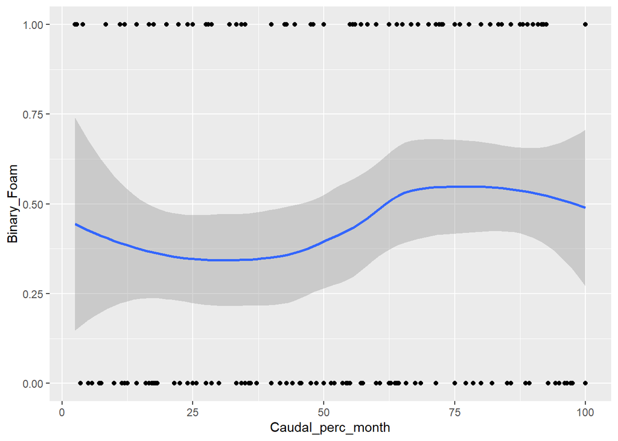

```r
ggplot(reg_caudales, aes(x = Caudal_perc_month, y = Binary_Foam)) + geom_point() + geom_smooth(se= TRUE)
```

```r
logLik(model)
```

```
## 'log Lik.' -130.2844 (df=2)
```

```r
# Chi cuadrado
anova(model, test = "Chisq")
```

```
## Analysis of Deviance Table
##
## Model: binomial, link: logit
##
## Response: Binary_Foam
##
## Terms added sequentially (first to last)
##
##
##                   Df Deviance Resid. Df Resid. Dev Pr(>Chi)
## NULL                                191     263.64
## Caudal_perc_month  1   3.0734       190     260.57  0.07959 .
## ---
## Signif. codes:  0 '***' 0.001 '**' 0.01 '*' 0.05 '.' 0.1 ' ' 1
```

```r
# Predicciones binarizadas usando 0.5 como umbral
predicted_class = ifelse(predict(model, type = "response") >= 0.5, 1, 0)

# Matriz de confusión
table(Predicted = predicted_class, Actual = reg_caudales$Binary_Foam)
```

```
##          Actual
## Predicted  0  1
##         0 85 62
##         1 22 23
```

```r
# Porcentaje de aciertos
mean(predicted_class == reg_caudales$Binary_Foam) * 100
```

```
## [1] 56.25
```

```r
model_2 = glm(Binary_Foam ~ CAUDAL, data = reg_caudales, family = binomial)

summary(model_2)
```

```
##
## Call:
## glm(formula = Binary_Foam ~ CAUDAL, family = binomial, data = reg_caudales)
##
## Coefficients:
##             Estimate Std. Error z value Pr(>|z|)
## (Intercept) -2.52840    0.56576  -4.469 7.86e-06 ***
## CAUDAL       0.09250    0.02262   4.090 4.32e-05 ***
## ---
## Signif. codes:  0 '***' 0.001 '**' 0.01 '*' 0.05 '.' 0.1 ' ' 1
##
## (Dispersion parameter for binomial family taken to be 1)
##
##     Null deviance: 263.64  on 191  degrees of freedom
## Residual deviance: 237.66  on 190  degrees of freedom
## AIC: 241.66
##
## Number of Fisher Scoring iterations: 5
```

```r
anova(model_2, test = "Chisq")
```

```
## Analysis of Deviance Table
##
## Model: binomial, link: logit
##
## Response: Binary_Foam
##
## Terms added sequentially (first to last)
##
##
##        Df Deviance Resid. Df Resid. Dev  Pr(>Chi)
## NULL                     191     263.64
## CAUDAL  1   25.979       190     237.66 3.452e-07 ***
## ---
## Signif. codes:  0 '***' 0.001 '**' 0.01 '*' 0.05 '.' 0.1 ' ' 1
```

```r
# Predict probabilities
probs <- predict(model_2, type = "response")

# Classify with a 0.5 threshold
pred_class <- ifelse(probs >= 0.5, 1, 0)

# Confusion matrix
table(Predicted = pred_class, Actual = reg_caudales$Binary_Foam)
```

```
##          Actual
## Predicted  0  1
##         0 90 48
##         1 17 37
```

```r
# Accuracy
mean(pred_class == reg_caudales$Binary_Foam) * 100
```

```
## [1] 66.14583
```

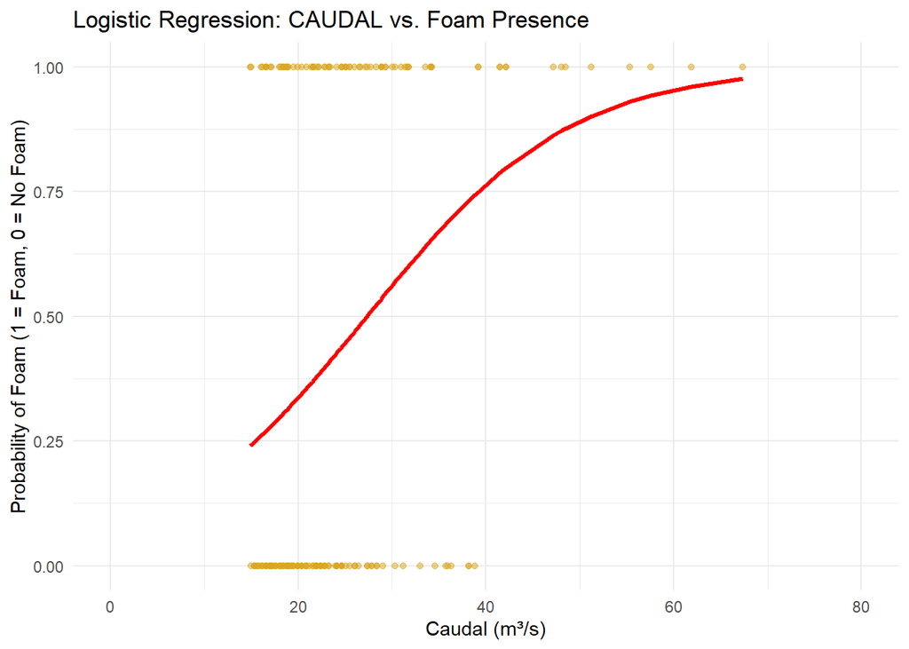

```r
ggplot(reg_caudales, aes(x = CAUDAL, y = Binary_Foam)) +
  geom_point(alpha = 0.5, color = "goldenrod") + xlim(0,80) +
  geom_line(aes(y = probs), color = "red", size = 1.2) +
  labs(title = "Logistic Regression: CAUDAL vs. Foam Presence",
       x = "Caudal (m³/s)",
       y = "Probability of Foam (1 = Foam, 0 = No Foam)") +
  theme_minimal()
```

```r
#COLD
final_caudales_cold_clean <- final_caudales_cold %>%
  filter(!is.na(CAUDAL), !is.na(Binary_Foam))

model_cold = glm(Binary_Foam ~ CAUDAL, data = final_caudales_cold_clean, family = binomial)

summary(model_cold)
```

```
##
## Call:
## glm(formula = Binary_Foam ~ CAUDAL, family = binomial, data = final_caudales_cold_clean)
##
## Coefficients:
##             Estimate Std. Error z value Pr(>|z|)
## (Intercept)  1.27031    2.43073   0.523    0.601
## CAUDAL       0.03016    0.06266   0.481    0.630
##
## (Dispersion parameter for binomial family taken to be 1)
##
##     Null deviance: 14.102  on 25  degrees of freedom
## Residual deviance: 13.697  on 24  degrees of freedom
## AIC: 17.697
##
## Number of Fisher Scoring iterations: 6
```

```r
anova(model_cold, test = "Chisq")
```

```
## Analysis of Deviance Table
##
## Model: binomial, link: logit
##
## Response: Binary_Foam
##
## Terms added sequentially (first to last)
##
##
##        Df Deviance Resid. Df Resid. Dev Pr(>Chi)
## NULL                      25     14.102
## CAUDAL  1  0.40456        24     13.697   0.5247
```

```r
# Predict probabilities
probs <- predict(model_cold, type = "response")

# Classify with a 0.5 threshold
pred_class <- ifelse(probs >= 0.5, 1, 0)

# Confusion matrix
table(Predicted = pred_class, Actual = final_caudales_cold_clean$Binary_Foam)
```

```
##          Actual
## Predicted  0  1
##         1  2 24
```

```r
# Accuracy
mean(pred_class == final_caudales_cold_clean$Binary_Foam) * 100
```

```
## [1] 92.30769
```

```r
#WARM
final_caudales_warm_clean = final_caudales_warm %>%
  filter(!is.na(CAUDAL), !is.na(Binary_Foam))

model_warm = glm(Binary_Foam ~ CAUDAL, data = final_caudales_warm_clean, family = binomial)

summary(model_warm)
```

```
##
## Call:
## glm(formula = Binary_Foam ~ CAUDAL, family = binomial, data = final_caudales_warm_clean)
##
## Coefficients:
##             Estimate Std. Error z value Pr(>|z|)
## (Intercept) -1.07233    0.79807  -1.344    0.179
## CAUDAL       0.02128    0.03342   0.637    0.524
##
## (Dispersion parameter for binomial family taken to be 1)
##
##     Null deviance: 123.92  on 94  degrees of freedom
## Residual deviance: 123.51  on 93  degrees of freedom
## AIC: 127.51
##
## Number of Fisher Scoring iterations: 4
```

```r
anova(model_warm, test = "Chisq")
```

```
## Analysis of Deviance Table
##
## Model: binomial, link: logit
##
## Response: Binary_Foam
##
## Terms added sequentially (first to last)
##
##
##        Df Deviance Resid. Df Resid. Dev Pr(>Chi)
## NULL                      94     123.92
## CAUDAL  1  0.40358        93     123.51   0.5252
```

```r
# Predict probabilities
probs <- predict(model_warm, type = "response")

# Classify with a 0.5 threshold
pred_class <- ifelse(probs >= 0.5, 1, 0)

# Confusion matrix
table(Predicted = pred_class, Actual = final_caudales_warm_clean$Binary_Foam)
```

```
##          Actual
## Predicted  0  1
##         0 61 33
##         1  0  1
```

```r
# Accuracy
mean(pred_class == final_caudales_warm_clean$Binary_Foam) * 100
```

```
## [1] 65.26316
```

> Los resultados de un p-valor de .0819 y una precisión baja (56.25%) indican que el percentil mensual del caudal muestra solo una relación débil con la presencia de espuma. Por sí solo, este indicador no permite predecir con precisión los eventos de espuma.

> En cambio, al usar el caudal absoluto, el model muestra una relación significativa con la presencia de espuma, p-valor de 4.32e-5. También mejora la precisión a 66.15%. Esto sugiere que los valores altos de caudal están más fuertemente asociados con la aparición de espuma, sin embargo es importante que averiguemos si hay otros factores que influyen estes resultos.

## Correlaciones con caudales

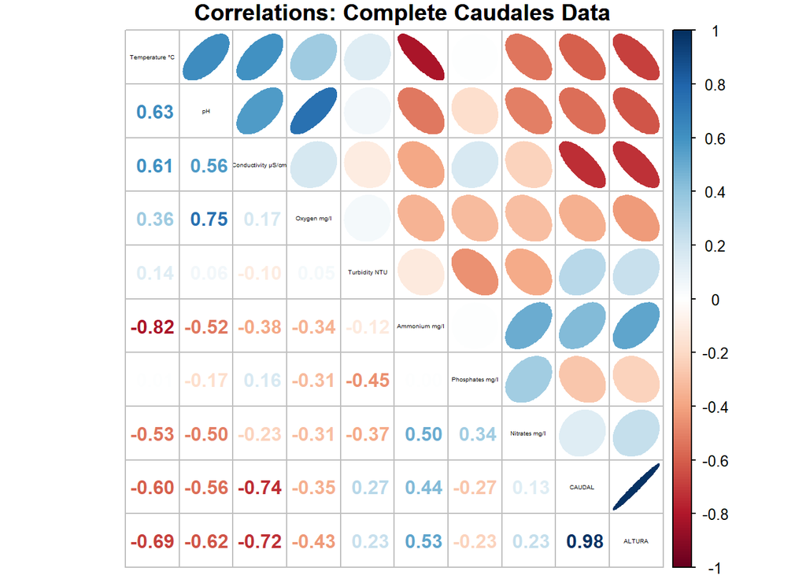

```r
cor_matrix_caud = final_caudales %>% select(where(is.numeric)) %>% cor(use = "complete.obs")

corrplot.mixed(cor_matrix_caud, upper = "ellipse",
  lower = "number",
  tl.col = "black",
  tl.cex = .3,
  number.cex = 1,
  mar = c(0, 0, 1, 0),
  main = "Correlations: Complete Caudales Data")
```

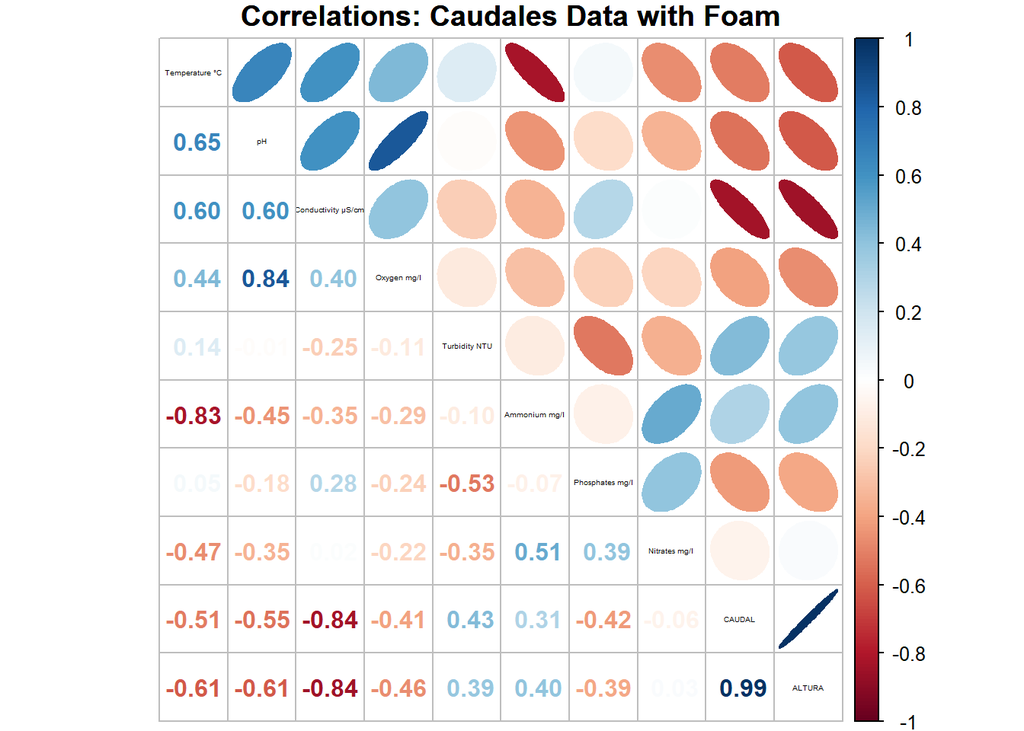

```r
#Reg_caudales SI ESPUMA
cor_matrix_caud_si = final_caudales %>% filter(Foam == "Yes") %>%  select(where(is.numeric)) %>% cor(use = "complete.obs")


corrplot.mixed(cor_matrix_caud_si, upper = "ellipse",
  lower = "number",
  tl.col = "black",
  tl.cex = .3,
  number.cex = 1,
  mar = c(0, 0, 1, 0),
  main = "Correlations: Caudales Data with Foam")
```

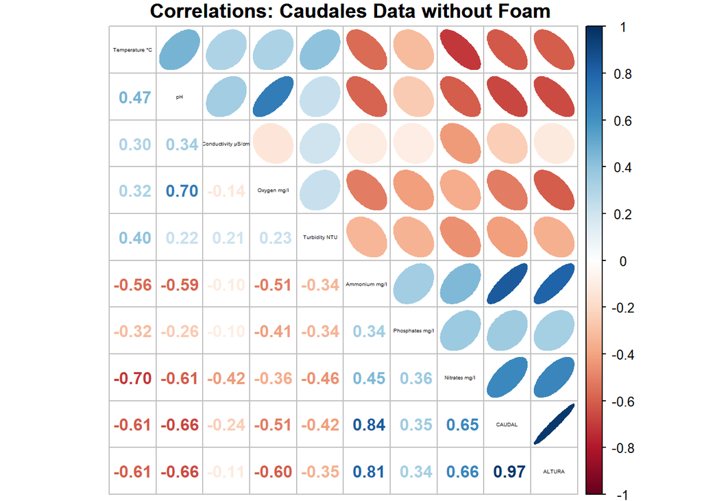

```r
#Reg_caudales NO ESPUMA
cor_matrix_caud_no = final_caudales %>% filter(Foam == "No") %>% select(where(is.numeric)) %>% cor(use = "complete.obs")


corrplot.mixed(cor_matrix_caud_no, upper = "ellipse",
  lower = "number",
  tl.col = "black",
  tl.cex = .3,
  number.cex = 1,
  mar = c(0, 0, 1, 0),
  main = "Correlations: Caudales Data without Foam")
```

> Hay una variabilidad alta entre los resultados de si espuma y no espuma, o sea es posible que hayan otras variables que influyen los resultados.

```r
final_data_reg = final_data

names(final_data_reg) <- make.names(names(final_data_reg))

final_data_reg = final_data_reg %>%
  filter(
    !is.na(Foam),
    !is.na(Temperature..C),
    !is.na(Ammonium.mg.l),
    !is.na(Oxygen.mg.l),
    !is.na(pH)
  ) %>%
  mutate(Binary_Foam = ifelse(Foam == "Yes", 1, 0))


model_3 = glm(Binary_Foam ~ Temperature..C + Ammonium.mg.l + Oxygen.mg.l + pH, data = final_data_reg, family = binomial)

summary(model_3)
```

```
##
## Call:
## glm(formula = Binary_Foam ~ Temperature..C + Ammonium.mg.l +
##     Oxygen.mg.l + pH, family = binomial, data = final_data_reg)
##
## Coefficients:
##                Estimate Std. Error z value Pr(>|z|)
## (Intercept)     3.87289    6.04187   0.641   0.5215
## Temperature..C -0.17637    0.07266  -2.428   0.0152 *
## Ammonium.mg.l   0.07097    0.16464   0.431   0.6664
## Oxygen.mg.l     0.12873    0.09323   1.381   0.1674
## pH             -0.16483    0.85682  -0.192   0.8474
## ---
## Signif. codes:  0 '***' 0.001 '**' 0.01 '*' 0.05 '.' 0.1 ' ' 1
##
## (Dispersion parameter for binomial family taken to be 1)
##
##     Null deviance: 179.73  on 129  degrees of freedom
## Residual deviance: 145.62  on 125  degrees of freedom
## AIC: 155.62
##
## Number of Fisher Scoring iterations: 5
```

```r
anova(model_3, test = "Chisq")
```

```
## Analysis of Deviance Table
##
## Model: binomial, link: logit
##
## Response: Binary_Foam
##
## Terms added sequentially (first to last)
##
##
##                Df Deviance Resid. Df Resid. Dev  Pr(>Chi)
## NULL                             129     179.73
## Temperature..C  1  31.3306       128     148.40 2.176e-08 ***
## Ammonium.mg.l   1   0.1215       127     148.27    0.7274
## Oxygen.mg.l     1   2.6135       126     145.66    0.1060
## pH              1   0.0369       125     145.62    0.8476
## ---
## Signif. codes:  0 '***' 0.001 '**' 0.01 '*' 0.05 '.' 0.1 ' ' 1
```

```r
# Predict probabilities
probs <- predict(model_3, type = "response")

# Classify with a 0.5 threshold
pred_class <- ifelse(probs >= 0.5, 1, 0)

# Confusion matrix
table(Predicted = pred_class, Actual = final_data_reg$Binary_Foam)
```

```
##          Actual
## Predicted  0  1
##         0 49 31
##         1 12 38
```

```r
# Accuracy
mean(pred_class == final_data_reg$Binary_Foam) * 100
```

```
## [1] 66.92308
```

# Regresion con temperatura

```r
reg_data = final_data %>% filter(!is.na(`Temperature °C`)) %>% mutate(Binary_Foam = ifelse(Foam == "Yes", 1, 0))
names(reg_data) <- make.names(names(reg_data))
model_temp = glm(Binary_Foam ~ Temperature..C, data = reg_data, family = binomial)
summary(model_temp)
```

```
##
## Call:
## glm(formula = Binary_Foam ~ Temperature..C, family = binomial,
##     data = reg_data)
##
## Coefficients:
##                Estimate Std. Error z value Pr(>|z|)
## (Intercept)     3.62856    0.73637   4.928 8.32e-07 ***
## Temperature..C -0.17314    0.03279  -5.280 1.29e-07 ***
## ---
## Signif. codes:  0 '***' 0.001 '**' 0.01 '*' 0.05 '.' 0.1 ' ' 1
##
## (Dispersion parameter for binomial family taken to be 1)
##
##     Null deviance: 228.73  on 164  degrees of freedom
## Residual deviance: 189.37  on 163  degrees of freedom
## AIC: 193.37
##
## Number of Fisher Scoring iterations: 4
```

```r
anova(model_temp, test = "Chisq")
```

```
## Analysis of Deviance Table
##
## Model: binomial, link: logit
##
## Response: Binary_Foam
##
## Terms added sequentially (first to last)
##
##
##                Df Deviance Resid. Df Resid. Dev  Pr(>Chi)
## NULL                             164     228.73
## Temperature..C  1   39.364       163     189.37 3.516e-10 ***
## ---
## Signif. codes:  0 '***' 0.001 '**' 0.01 '*' 0.05 '.' 0.1 ' ' 1
```

```r
probs = predict(model_temp, type= "response")
pred_class = ifelse(probs >= .5, 1, 0)
table(Predicted = pred_class, Actual = reg_data$Binary_Foam)
```

```
##          Actual
## Predicted  0  1
##         0 70 37
##         1 12 46
```

```r
mean(pred_class == reg_data$Binary_Foam) * 100
```

```
## [1] 70.30303
```

# Regresion con amonio

```r
reg2_data = final_data %>% filter(!is.na(`Ammonium mg/l`)) %>% mutate(Binary_Foam = ifelse(Foam == "Yes", 1, 0))
names(reg2_data) = make.names(names(reg2_data))
model_amm = glm(Binary_Foam ~ Ammonium.mg.l, data = reg2_data, family = binomial)
summary(model_amm)
```

```
##
## Call:
## glm(formula = Binary_Foam ~ Ammonium.mg.l, family = binomial,
##     data = reg2_data)
##
## Coefficients:
##               Estimate Std. Error z value Pr(>|z|)
## (Intercept)    -0.5619     0.2254  -2.492 0.012688 *
## Ammonium.mg.l   0.3983     0.1032   3.859 0.000114 ***
## ---
## Signif. codes:  0 '***' 0.001 '**' 0.01 '*' 0.05 '.' 0.1 ' ' 1
##
## (Dispersion parameter for binomial family taken to be 1)
##
##     Null deviance: 192.11  on 138  degrees of freedom
## Residual deviance: 165.22  on 137  degrees of freedom
## AIC: 169.22
##
## Number of Fisher Scoring iterations: 5
```

```r
anova(model_amm, test = "Chisq")
```

```
## Analysis of Deviance Table
##
## Model: binomial, link: logit
##
## Response: Binary_Foam
##
## Terms added sequentially (first to last)
##
##
##               Df Deviance Resid. Df Resid. Dev  Pr(>Chi)
## NULL                            138     192.11
## Ammonium.mg.l  1   26.896       137     165.22 2.147e-07 ***
## ---
## Signif. codes:  0 '***' 0.001 '**' 0.01 '*' 0.05 '.' 0.1 ' ' 1
```

```r
probs = predict(model_amm, type = "response")
pred_class = ifelse(probs >= .5, 1, 0)
table(Predicted = pred_class, Actual = reg2_data$Binary_Foam)
```

```
##          Actual
## Predicted  0  1
##         0 53 37
##         1 12 37
```

```r
mean(pred_class == reg2_data$Binary_Foam) * 100
```

```
## [1] 64.7482
```

# Regresion con amonio y temperatura

```r
reg3_data = final_data %>% filter(!is.na(`Ammonium mg/l`), !is.na(`Temperature °C`)) %>% mutate(Binary_Foam = ifelse(Foam == "Yes", 1, 0))
names(reg3_data) = make.names(names(reg3_data))
model_temp.amm = glm(Binary_Foam ~ Ammonium.mg.l + Temperature..C, data = reg3_data, family = binomial)
summary(model_temp.amm)
```

```
##
## Call:
## glm(formula = Binary_Foam ~ Ammonium.mg.l + Temperature..C, family = binomial,
##     data = reg3_data)
##
## Coefficients:
##                Estimate Std. Error z value Pr(>|z|)
## (Intercept)     3.20442    1.64586   1.947   0.0515 .
## Ammonium.mg.l   0.06696    0.15650   0.428   0.6688
## Temperature..C -0.15103    0.06547  -2.307   0.0211 *
## ---
## Signif. codes:  0 '***' 0.001 '**' 0.01 '*' 0.05 '.' 0.1 ' ' 1
##
## (Dispersion parameter for binomial family taken to be 1)
##
##     Null deviance: 183.77  on 132  degrees of freedom
## Residual deviance: 151.70  on 130  degrees of freedom
## AIC: 157.7
##
## Number of Fisher Scoring iterations: 5
```

```r
anova(model_temp.amm, test = "Chisq")
```

```
## Analysis of Deviance Table
##
## Model: binomial, link: logit
##
## Response: Binary_Foam
##
## Terms added sequentially (first to last)
##
##
##                Df Deviance Resid. Df Resid. Dev  Pr(>Chi)
## NULL                             132     183.77
## Ammonium.mg.l   1  25.9709       131     157.80 3.466e-07 ***
## Temperature..C  1   6.0973       130     151.70   0.01354 *
## ---
## Signif. codes:  0 '***' 0.001 '**' 0.01 '*' 0.05 '.' 0.1 ' ' 1
```

```r
probs = predict(model_temp.amm, type = "response")
pred_class = ifelse(probs >= .5, 1, 0)
table(Predicted = pred_class, Actual = reg3_data$Binary_Foam)
```

```
##          Actual
## Predicted  0  1
##         0 50 31
##         1 12 40
```

```r
mean(pred_class == reg3_data$Binary_Foam) * 100
```

```
## [1] 67.66917
```

# Tabla de medianas contra q3 en Safont

```r
translation_dict_puente = c(
  "nombre_estacion" = "station_name",
  "fecha" = "Date",
  "Temperatura °C" = "Temperature °C",
  "pH" = "pH",
  "Conductividad µS/cm" = "Conductivity µS/cm",
  "Oxígeno mg/l" = "Oxygen mg/l",
  "Turbidez NTU" = "Turbidity NTU",
  "Amonio mg/l" = "Ammonium mg/l",
  "Fosfatos mg/l" = "Phosphates mg/l"
)

puente_largo_2016 = puente_largo %>% mutate(Year = year(fecha)) %>% filter(Year >= 2016 & Year <= 2021)
puente_largo_2016 = puente_largo_2016 %>%
  rename_with(~ translation_dict_puente[.x], .cols = names(translation_dict_puente))



# -----------------------------------------
# 1. Foam event dates
# -----------------------------------------

foam_days <- final_data %>%
  filter(Foam == "Yes") %>%
  pull(Date) %>%
  as.Date()

# -----------------------------------------
# 2. Overall Q3 for entire SAFONT dataset
# -----------------------------------------

overall_q3_safont <- safont_2016 %>%
  summarise(across(
    where(is.numeric),
    ~ quantile(.x, 0.75, na.rm = TRUE)
  )) %>% select(-Year)

# -----------------------------------------
# 3. Daily medians for foam days
# -----------------------------------------

daily_medians <- safont_2016 %>%
  filter(as.Date(Date) %in% foam_days) %>%
  mutate(Event_Date = as.Date(Date)) %>%
  group_by(Event_Date) %>%
  summarise(across(
    where(is.numeric),
    ~ median(.x, na.rm = TRUE)
  )) %>%
  ungroup() %>% select(-Year)

# -----------------------------------------
# 4. Compare daily medians to overall Q3
# -----------------------------------------

compare_cols <- names(overall_q3_safont)

for (var in compare_cols) {

  daily_col <- var
  new_col <- paste0(var, "_Muy_Alto")

  if (daily_col %in% names(daily_medians)) {

    daily_medians[[new_col]] <- ifelse(
      is.na(daily_medians[[daily_col]]),
      NA,
      daily_medians[[daily_col]] > overall_q3_safont[[var]]
    )

  } else {
    message("Skipping ", var,
            " because ", daily_col, " not found in daily_medians.")
  }
}

# -----------------------------------------
# 5. Prepare long-format data for heatmap
# -----------------------------------------

plot_df <- daily_medians %>%
  select(Event_Date, ends_with("_Muy_Alto")) %>%
  pivot_longer(
    cols = -Event_Date,
    names_to = "Variable",
    values_to = "Muy_Alto"
  ) %>%
  mutate(
    Variable = gsub("_Muy_Alto$", "", Variable),
    Muy_Alto = case_when(
      is.na(Muy_Alto) ~ "NA",
      Muy_Alto == TRUE ~ "Very High",
      TRUE ~ "Normal"
    )
  )

# Add numeric values for labeling:
plot_df <- plot_df %>%
  left_join(
    daily_medians %>%
      select(Event_Date, all_of(compare_cols)) %>%
      pivot_longer(
        cols = -Event_Date,
        names_to = "Variable",
        values_to = "Value"
      ),
    by = c("Event_Date", "Variable")
  )

# -----------------------------------------
# 6. Create "Overall Q3" row
# -----------------------------------------

overall_q3_row <- overall_q3_safont %>%
  pivot_longer(
    cols = everything(),
    names_to = "Variable",
    values_to = "Value"
  ) %>%
  mutate(
    Event_Date = "Overall Q3",
    Muy_Alto = "Overall"
  )

# -----------------------------------------
# 7. Summaries: red counts and percentages
# -----------------------------------------

summary_counts <- plot_df %>%
  filter(Muy_Alto == "Very High") %>%
  group_by(Variable) %>%
  summarise(Red_Count = n()) %>%
  right_join(
    plot_df %>%
      group_by(Variable) %>%
      summarise(Total = n_distinct(Event_Date)),
    by = "Variable"
  ) %>%
  mutate(
    Red_Count = replace_na(Red_Count, 0),
    Percent_Red = round((Red_Count / Total) * 100, 1)
  )

# Create summary rows
red_count_row <- summary_counts %>%
  mutate(
    Event_Date = "Number of Very High Events",
    Muy_Alto = "Summary",
    Value = Red_Count
  ) %>%
  select(Variable, Event_Date, Muy_Alto, Value)

percent_red_row <- summary_counts %>%
  mutate(
    Event_Date = "Percentage of Very High Events",
    Muy_Alto = "Summary",
    Value = Percent_Red
  ) %>%
  select(Variable, Event_Date, Muy_Alto, Value)

# -----------------------------------------
# 8. Combine everything for plotting
# -----------------------------------------
plot_df$Event_Date = as.character(plot_df$Event_Date)
plot_data_augmented <- bind_rows(
  overall_q3_row,
  plot_df %>% select(Variable, Event_Date, Muy_Alto, Value),
  red_count_row,
  percent_red_row
)

# Order rows for plot
plot_data_augmented$Event_Date <- factor(
  plot_data_augmented$Event_Date,
  levels = c(
    "Overall Q3",
    sort(unique(as.character(plot_df$Event_Date))),
    "Number of Very High Events",
    "Percentage of Very High Events"
  )
)

# -----------------------------------------
# 9. Plot the heatmap
# -----------------------------------------

fill_colors <- c(
  "Very High" = "tomato",
  "Normal" = "skyblue",
  "NA" = "grey",
  "Overall" = "khaki",
  "Summary" = "lavender"
)

p <- ggplot(
  plot_data_augmented,
  aes(
    x = Variable,
    y = Event_Date,
    fill = Muy_Alto
  )
) +
  geom_tile(color = "white") +
  geom_text(
    aes(label = round(Value, 2)),
    size = 2.5,
    color = "black"
  ) +
  scale_fill_manual(
    values = fill_colors,
    name = "Category"
  ) +
  labs(
    title = "Daily Median vs Overall Q3 - SAFONT",
    x = "Variable",
    y = "Foam Event Date"
  ) +
  theme_minimal() +
  theme(
    axis.text.x = element_text(angle = 45, hjust = 1, color = "black"),
    axis.text.y = element_text(size = 6, color = "black"),
    axis.title = element_text(color = "black"),
    plot.title = element_text(color = "black"),
    plot.background = element_rect(fill = "white", color = NA),
    panel.background = element_rect(fill = "white", color = NA),
    legend.background = element_rect(fill = "white", color = NA),
    legend.key = element_rect(fill = "white", color = NA),
    legend.text = element_text(color = "black"),
    legend.title = element_text(color = "black")
  )

# Save the plot
ggsave("heatmap_with_overall_q3_safont_medianas.png", p, width = 20, height = 12, dpi = 300)
```

# Tabla de medias contra q3 en Safont

```r
# -----------------------------------------
# 1. Foam event dates
# -----------------------------------------

foam_days <- final_data %>%
  filter(Foam == "Yes") %>%
  pull(Date) %>%
  as.Date()

# -----------------------------------------
# 2. Overall Q3 for entire SAFONT dataset
# -----------------------------------------

overall_q3_safont <- safont_2016 %>%
  summarise(across(
    where(is.numeric),
    ~ quantile(.x, 0.75, na.rm = TRUE)
  )) %>% select(-Year)

# -----------------------------------------
# 3. Daily medians for foam days
# -----------------------------------------

daily_means <- safont_2016 %>%
  filter(as.Date(Date) %in% foam_days) %>%
  mutate(Event_Date = as.Date(Date)) %>%
  group_by(Event_Date) %>%
  summarise(across(
    where(is.numeric),
    ~ mean(.x, na.rm = TRUE)
  )) %>%
  ungroup() %>% select(-Year)

# -----------------------------------------
# 4. Compare daily medians to overall Q3
# -----------------------------------------

compare_cols <- names(overall_q3_safont)

for (var in compare_cols) {

  daily_col <- var
  new_col <- paste0(var, "_Muy_Alto")

  if (daily_col %in% names(daily_means)) {

    daily_means[[new_col]] <- ifelse(
      is.na(daily_means[[daily_col]]),
      NA,
      daily_means[[daily_col]] > overall_q3_safont[[var]]
    )

  } else {
    message("Skipping ", var,
            " because ", daily_col, " not found in daily_medians.")
  }
}

# -----------------------------------------
# 5. Prepare long-format data for heatmap
# -----------------------------------------

plot_df <- daily_means %>%
  select(Event_Date, ends_with("_Muy_Alto")) %>%
  pivot_longer(
    cols = -Event_Date,
    names_to = "Variable",
    values_to = "Muy_Alto"
  ) %>%
  mutate(
    Variable = gsub("_Muy_Alto$", "", Variable),
    Muy_Alto = case_when(
      is.na(Muy_Alto) ~ "NA",
      Muy_Alto == TRUE ~ "Very High",
      TRUE ~ "Normal"
    )
  )

# Add numeric values for labeling:
plot_df <- plot_df %>%
  left_join(
    daily_means %>%
      select(Event_Date, all_of(compare_cols)) %>%
      pivot_longer(
        cols = -Event_Date,
        names_to = "Variable",
        values_to = "Value"
      ),
    by = c("Event_Date", "Variable")
  )

# -----------------------------------------
# 6. Create "Overall Q3" row
# -----------------------------------------

overall_q3_row <- overall_q3_safont %>%
  pivot_longer(
    cols = everything(),
    names_to = "Variable",
    values_to = "Value"
  ) %>%
  mutate(
    Event_Date = "Overall Q3",
    Muy_Alto = "Overall"
  )

# -----------------------------------------
# 7. Summaries: red counts and percentages
# -----------------------------------------

summary_counts <- plot_df %>%
  filter(Muy_Alto == "Very High") %>%
  group_by(Variable) %>%
  summarise(Red_Count = n()) %>%
  right_join(
    plot_df %>%
      group_by(Variable) %>%
      summarise(Total = n_distinct(Event_Date)),
    by = "Variable"
  ) %>%
  mutate(
    Red_Count = replace_na(Red_Count, 0),
    Percent_Red = round((Red_Count / Total) * 100, 1)
  )

# Create summary rows
red_count_row <- summary_counts %>%
  mutate(
    Event_Date = "Number of Very High Events",
    Muy_Alto = "Summary",
    Value = Red_Count
  ) %>%
  select(Variable, Event_Date, Muy_Alto, Value)

percent_red_row <- summary_counts %>%
  mutate(
    Event_Date = "Percentage of Very High Events",
    Muy_Alto = "Summary",
    Value = Percent_Red
  ) %>%
  select(Variable, Event_Date, Muy_Alto, Value)

# -----------------------------------------
# 8. Combine everything for plotting
# -----------------------------------------
plot_df$Event_Date = as.character(plot_df$Event_Date)
plot_data_augmented <- bind_rows(
  overall_q3_row,
  plot_df %>% select(Variable, Event_Date, Muy_Alto, Value),
  red_count_row,
  percent_red_row
)

# Order rows for plot
plot_data_augmented$Event_Date <- factor(
  plot_data_augmented$Event_Date,
  levels = c(
    "Overall Q3",
    sort(unique(as.character(plot_df$Event_Date))),
    "Number of Very High Events",
    "Percentage of Very High Events"
  )
)

# -----------------------------------------
# 9. Plot the heatmap
# -----------------------------------------

fill_colors <- c(
  "Very High" = "tomato",
  "Normal" = "skyblue",
  "NA" = "grey",
  "Overall" = "khaki",
  "Summary" = "lavender"
)

p <- ggplot(
  plot_data_augmented,
  aes(
    x = Variable,
    y = Event_Date,
    fill = Muy_Alto
  )
) +
  geom_tile(color = "white") +
  geom_text(
    aes(label = round(Value, 2)),
    size = 2.5,
    color = "black"
  ) +
  scale_fill_manual(
    values = fill_colors,
    name = "Category"
  ) +
  labs(
    title = "Daily Mean vs Overall Q3 - SAFONT",
    x = "Variable",
    y = "Foam Event Date"
  ) +
  theme_minimal() +
  theme(
    axis.text.x = element_text(angle = 45, hjust = 1, color = "black"),
    axis.text.y = element_text(size = 6, color = "black"),
    axis.title = element_text(color = "black"),
    plot.title = element_text(color = "black"),
    plot.background = element_rect(fill = "white", color = NA),
    panel.background = element_rect(fill = "white", color = NA),
    legend.background = element_rect(fill = "white", color = NA),
    legend.key = element_rect(fill = "white", color = NA),
    legend.text = element_text(color = "black"),
    legend.title = element_text(color = "black")
  )

# Save the plot
ggsave("heatmap_with_overall_q3_safont_medias.png", p, width = 20, height = 12, dpi = 300)
```

# Tabla de medias contra q3 en Puente Largo

```r
library(tidyverse)
library(lubridate)

# ---------------------------------------------
# 1. Prepare foam days
# ---------------------------------------------

foam_days <- final_data %>%
  filter(Foam == "Yes") %>%
  pull(Date) %>%
  as.POSIXct(origin = "1970-01-01", tz = "UTC")

# ---------------------------------------------
# 2. Ensure Puente Largo dates are POSIXct
# ---------------------------------------------

puente_largo_2016$Date <- as.POSIXct(puente_largo_2016$Date, tz = "UTC")

# ---------------------------------------------
# 3. Compute means for each foam day using MAP
# ---------------------------------------------

compute_window_means <- function(t) {

  window_start <- t - hours(38)
  window_end   <- t - hours(26)

  window_data <- puente_largo_2016 %>%
    filter(Date >= window_start,
           Date <= window_end)


  if (nrow(window_data) == 0) {
    return(NULL)
  }


  means <- window_data %>%
  summarise(
    across(
      where(is.numeric),
      ~ {
        if (all(is.na(.x))) NA_real_ else mean(.x, na.rm = TRUE)
      }
    )
  ) %>%
  mutate(
    Foam_Event_Date = as.Date(t),
    Rows_In_Window = nrow(window_data)
  )

  return(means)
}

# Apply function to all foam days
results_list <- map(foam_days, compute_window_means)
results_list <- compact(results_list)

# Bind into a single data frame
if (length(results_list) > 0) {
  daily_means_puente <- bind_rows(results_list)
} else {
  stop("No data windows found.")
}

# ---------------------------------------------
# 4. Compute overall Q3 for entire Puente Largo
# ---------------------------------------------

overall_q3_puente <- puente_largo_2016 %>%
  summarise(across(
    where(is.numeric),
    ~ quantile(.x, 0.75, na.rm = TRUE)
  ))

# Drop Year if exists
overall_q3_puente <- overall_q3_puente %>%
  select(-Year)

print(overall_q3_puente)
```

```
## # A tibble: 1 × 7
##   `Temperature °C`    pH `Conductivity µS/cm` `Oxygen mg/l` `Turbidity NTU`
##              <dbl> <dbl>                <dbl>         <dbl>           <dbl>
## 1               22   7.5                 1539           6.2              26
## # ℹ 2 more variables: `Ammonium mg/l` <dbl>, `Phosphates mg/l` <dbl>
```

```r
# ---------------------------------------------
# 5. Compare daily means to overall Q3
# ---------------------------------------------

compare_cols <- names(overall_q3_puente)

for (var in compare_cols) {

  daily_col <- var
  new_col <- paste0(var, "_Muy_Alto")

  if (daily_col %in% names(daily_means_puente)) {
    daily_means_puente[[new_col]] <- ifelse(
      is.na(daily_means_puente[[daily_col]]),
      NA,
      daily_means_puente[[daily_col]] > overall_q3_puente[[var]]
    )
  } else {
    message("Skipping ", var, " because ", daily_col, " not found in daily_means_puente.")
  }
}

# ---------------------------------------------
# 6. Prepare data for heatmap
# ---------------------------------------------

plot_df <- daily_means_puente %>%
  select(Foam_Event_Date, ends_with("_Muy_Alto")) %>%
  pivot_longer(
    cols = -Foam_Event_Date,
    names_to = "Variable",
    values_to = "Muy_Alto"
  ) %>%
  mutate(
    Variable = gsub("_Muy_Alto$", "", Variable),
    Muy_Alto = case_when(
      is.na(Muy_Alto) ~ "NA",
      Muy_Alto == TRUE ~ "Very High",
      TRUE ~ "Normal"
    )
  )

# Add numeric mean values for display
plot_df <- plot_df %>%
  left_join(
    daily_means_puente %>%
      select(Foam_Event_Date, all_of(compare_cols)) %>%
      pivot_longer(
        cols = -Foam_Event_Date,
        names_to = "Variable",
        values_to = "Value"
      ),
    by = c("Foam_Event_Date", "Variable")
  )

# ---------------------------------------------
# 7. Create overall Q3 row
# ---------------------------------------------

overall_q3_row <- overall_q3_puente %>%
  pivot_longer(
    cols = everything(),
    names_to = "Variable",
    values_to = "Value"
  ) %>%
  mutate(
    Foam_Event_Date = "Overall Q3",
    Muy_Alto = "Overall"
  )

# ---------------------------------------------
# 8. Summaries: red counts & percent red
# ---------------------------------------------

summary_counts <- plot_df %>%
  filter(Muy_Alto == "Very High") %>%
  group_by(Variable) %>%
  summarise(Red_Count = n()) %>%
  right_join(
    plot_df %>%
      group_by(Variable) %>%
      summarise(Total = n_distinct(Foam_Event_Date)),
    by = "Variable"
  ) %>%
  mutate(
    Red_Count = replace_na(Red_Count, 0),
    Percent_Red = round((Red_Count / Total) * 100, 1)
  )

# Prepare summary rows
red_count_row <- summary_counts %>%
  mutate(
    Foam_Event_Date = "Number of Very High Events",
    Muy_Alto = "Summary",
    Value = Red_Count
  ) %>%
  select(Variable, Foam_Event_Date, Muy_Alto, Value)

percent_red_row <- summary_counts %>%
  mutate(
    Foam_Event_Date = "Percentage of Very High Events",
    Muy_Alto = "Summary",
    Value = Percent_Red
  ) %>%
  select(Variable, Foam_Event_Date, Muy_Alto, Value)

# ---------------------------------------------
# 9. Combine all rows for plotting
# ---------------------------------------------

plot_df$Foam_Event_Date <- as.character(plot_df$Foam_Event_Date)

plot_data_augmented <- bind_rows(
  overall_q3_row,
  plot_df %>% select(Variable, Foam_Event_Date, Muy_Alto, Value),
  red_count_row,
  percent_red_row
)

plot_data_augmented$Foam_Event_Date <- factor(
  plot_data_augmented$Foam_Event_Date,
  levels = c(
    "Overall Q3",
    sort(unique(as.character(plot_df$Foam_Event_Date))),
    "Number of Very High Events",
    "Percentage of Very High Events"
  )
)

# ---------------------------------------------
# 10. Plot the heatmap
# ---------------------------------------------

fill_colors <- c(
  "Very High" = "tomato",
  "Normal" = "skyblue",
  "NA" = "grey",
  "Overall" = "khaki",
  "Summary" = "lavender"
)

p <- ggplot(
  plot_data_augmented,
  aes(
    x = Variable,
    y = Foam_Event_Date,
    fill = Muy_Alto
  )
) +
  geom_tile(color = "white") +
  geom_text(
    aes(label = round(Value, 2)),
    size = 2.5,
    color = "black"
  ) +
  scale_fill_manual(
    values = fill_colors,
    name = "Category"
  ) +
  labs(
    title = "Daily Mean vs Overall Q3 - PUENTE LARGO",
    x = "Variable",
    y = "Foam Event Date"
  ) +
  theme_minimal() +
  theme(
    axis.text.x = element_text(angle = 45, hjust = 1, color = "black"),
    axis.text.y = element_text(size = 6, color = "black"),
    axis.title = element_text(color = "black"),
    plot.title = element_text(color = "black"),
    plot.background = element_rect(fill = "white", color = NA),
    panel.background = element_rect(fill = "white", color = NA),
    legend.background = element_rect(fill = "white", color = NA),
    legend.key = element_rect(fill = "white", color = NA),
    legend.text = element_text(color = "black"),
    legend.title = element_text(color = "black")
  )

ggsave("heatmap_with_overall_q3_puentelargo_means.png", p, width = 20, height = 12, dpi = 300)
```

# Tabla de medianas contra q3 en Puente Largo

```r
library(tidyverse)
library(lubridate)

# ---------------------------------------------
# 1. Prepare foam days
# ---------------------------------------------

foam_days <- final_data %>%
  filter(Foam == "Yes") %>%
  pull(Date) %>%
  as.POSIXct(origin = "1970-01-01", tz = "UTC")


# ---------------------------------------------
# 2. Ensure Puente Largo dates are POSIXct
# ---------------------------------------------

puente_largo_2016$Date <- as.POSIXct(puente_largo_2016$Date, tz = "UTC")

# ---------------------------------------------
# 3. Compute medians for each foam day using MAP
# ---------------------------------------------

compute_window_medians <- function(t) {

  window_start <- t - hours(38)
  window_end   <- t - hours(26)

  window_data <- puente_largo_2016 %>%
    filter(Date >= window_start,
           Date <= window_end)


  if (nrow(window_data) == 0) {
    return(NULL)
  }

  medians <- window_data %>%
  summarise(across(where(is.numeric), ~ median(.x, na.rm = TRUE))) %>%
  mutate(Foam_Event_Date = as.Date(t))

  return(medians)
}

# Apply function to all foam days
results_list <- map(foam_days, compute_window_medians)
results_list <- compact(results_list)

# Bind into a single data frame
if (length(results_list) > 0) {
  daily_medians_puente <- bind_rows(results_list)
} else {
  stop("No data windows found.")
}

# ---------------------------------------------
# 4. Compute overall Q3 for entire Puente Largo
# ---------------------------------------------

overall_q3_puente <- puente_largo_2016 %>%
  summarise(across(
    where(is.numeric),
    ~ quantile(.x, 0.75, na.rm = TRUE)
  ))

# Drop Year if exists
overall_q3_puente <- overall_q3_puente %>% select(-Year)

print(overall_q3_puente)
```

```
## # A tibble: 1 × 7
##   `Temperature °C`    pH `Conductivity µS/cm` `Oxygen mg/l` `Turbidity NTU`
##              <dbl> <dbl>                <dbl>         <dbl>           <dbl>
## 1               22   7.5                 1539           6.2              26
## # ℹ 2 more variables: `Ammonium mg/l` <dbl>, `Phosphates mg/l` <dbl>
```

```r
# ---------------------------------------------
# 5. Compare daily means to overall Q3
# ---------------------------------------------

compare_cols <- names(overall_q3_puente)

for (var in compare_cols) {

  daily_col <- var
  new_col <- paste0(var, "_Muy_Alto")

  if (daily_col %in% names(daily_medians_puente)) {
    daily_medians_puente[[new_col]] <- ifelse(
      is.na(daily_medians_puente[[daily_col]]),
      NA,
      daily_medians_puente[[daily_col]] > overall_q3_puente[[var]]
    )
  } else {
    message("Skipping ", var, " because ", daily_col, " not found in daily_medians_puente.")
  }
}

# ---------------------------------------------
# 6. Prepare data for heatmap
# ---------------------------------------------

plot_df <- daily_medians_puente %>%
  select(Foam_Event_Date, ends_with("_Muy_Alto")) %>%
  pivot_longer(
    cols = -Foam_Event_Date,
    names_to = "Variable",
    values_to = "Muy_Alto"
  ) %>%
  mutate(
    Variable = gsub("_Muy_Alto$", "", Variable),
    Muy_Alto = case_when(
      is.na(Muy_Alto) ~ "NA",
      Muy_Alto == TRUE ~ "Very High",
      TRUE ~ "Normal"
    )
  )

# Add numeric mean values for display
plot_df <- plot_df %>%
  left_join(
    daily_medians_puente %>%
      select(Foam_Event_Date, all_of(compare_cols)) %>%
      pivot_longer(
        cols = -Foam_Event_Date,
        names_to = "Variable",
        values_to = "Value"
      ),
    by = c("Foam_Event_Date", "Variable")
  )

# ---------------------------------------------
# 7. Create overall Q3 row
# ---------------------------------------------

overall_q3_row <- overall_q3_puente %>%
  pivot_longer(
    cols = everything(),
    names_to = "Variable",
    values_to = "Value"
  ) %>%
  mutate(
    Foam_Event_Date = "Overall Q3",
    Muy_Alto = "Overall"
  )

# ---------------------------------------------
# 8. Summaries: red counts & percent red
# ---------------------------------------------

summary_counts <- plot_df %>%
  filter(Muy_Alto == "Very High") %>%
  group_by(Variable) %>%
  summarise(Red_Count = n()) %>%
  right_join(
    plot_df %>%
      group_by(Variable) %>%
      summarise(Total = n_distinct(Foam_Event_Date)),
    by = "Variable"
  ) %>%
  mutate(
    Red_Count = replace_na(Red_Count, 0),
    Percent_Red = round((Red_Count / Total) * 100, 1)
  )

# Prepare summary rows
red_count_row <- summary_counts %>%
  mutate(
    Foam_Event_Date = "Number of Very High Events",
    Muy_Alto = "Summary",
    Value = Red_Count
  ) %>%
  select(Variable, Foam_Event_Date, Muy_Alto, Value)

percent_red_row <- summary_counts %>%
  mutate(
    Foam_Event_Date = "Percentage of Very High Events",
    Muy_Alto = "Summary",
    Value = Percent_Red
  ) %>%
  select(Variable, Foam_Event_Date, Muy_Alto, Value)

# ---------------------------------------------
# 9. Combine all rows for plotting
# ---------------------------------------------

plot_df$Foam_Event_Date <- as.character(plot_df$Foam_Event_Date)

plot_data_augmented <- bind_rows(
  overall_q3_row,
  plot_df %>% select(Variable, Foam_Event_Date, Muy_Alto, Value),
  red_count_row,
  percent_red_row
)

plot_data_augmented$Foam_Event_Date <- factor(
  plot_data_augmented$Foam_Event_Date,
  levels = c(
    "Overall Q3",
    sort(unique(as.character(plot_df$Foam_Event_Date))),
    "Number of Very High Events",
    "Percentage of Very High Events"
  )
)

# ---------------------------------------------
# 10. Plot the heatmap
# ---------------------------------------------

fill_colors <- c(
  "Very High" = "tomato",
  "Normal" = "skyblue",
  "NA" = "grey",
  "Overall" = "khaki",
  "Summary" = "lavender"
)

p <- ggplot(
  plot_data_augmented,
  aes(
    x = Variable,
    y = Foam_Event_Date,
    fill = Muy_Alto
  )
) +
  geom_tile(color = "white") +
  geom_text(
    aes(label = round(Value, 2)),
    size = 2.5,
    color = "black"
  ) +
  scale_fill_manual(
    values = fill_colors,
    name = "Category"
  ) +
  labs(
    title = "Daily Median vs Overall Q3 - PUENTE LARGO",
    x = "Variable",
    y = "Foam Event Date"
  ) +
  theme_minimal() +
  theme(
    axis.text.x = element_text(angle = 45, hjust = 1, color = "black"),
    axis.text.y = element_text(size = 6, color = "black"),
    axis.title = element_text(color = "black"),
    plot.title = element_text(color = "black"),
    plot.background = element_rect(fill = "white", color = NA),
    panel.background = element_rect(fill = "white", color = NA),
    legend.background = element_rect(fill = "white", color = NA),
    legend.key = element_rect(fill = "white", color = NA),
    legend.text = element_text(color = "black"),
    legend.title = element_text(color = "black")
  )

ggsave("heatmap_with_overall_q3_puentelargo_medians.png", p, width = 20, height = 12, dpi = 300)
```

# Puente Largo contra Safont Grafica de Amonio

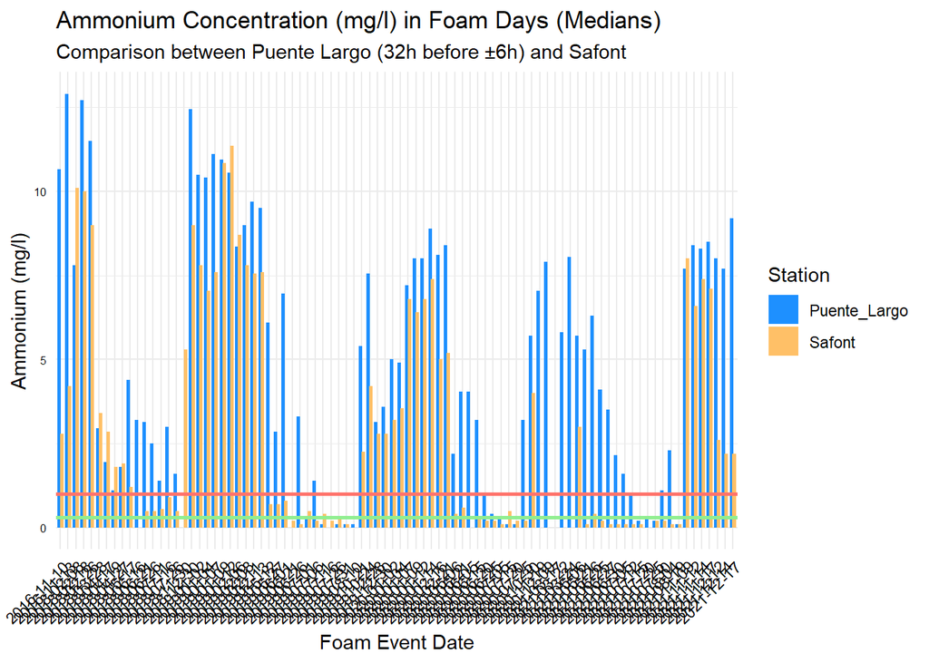

```r
# Puente Largo: keep only Ammonium and date
puente_ammonium = daily_medians_puente %>%
  select(Foam_Event_Date, `Ammonium mg/l`) %>%
  rename(Puente_Largo = `Ammonium mg/l`)

# Safont: keep only Ammonium and date
safont_ammonium <- daily_medians %>%
  select(Event_Date, `Ammonium mg/l`) %>%
  rename(Safont = `Ammonium mg/l`,
         Foam_Event_Date = Event_Date)

# Merge them
ammonium_data = full_join(puente_ammonium, safont_ammonium, by = "Foam_Event_Date")

# Pivot longer for ggplot
ammonium_long = ammonium_data %>%
  pivot_longer(
    cols = c(Puente_Largo, Safont),
    names_to = "Station",
    values_to = "Ammonium_mg_l"
  )

limite_bueno_moderado <- 1
limite_muy_bueno_bueno <- 0.3

# Plot
ggplot(ammonium_long, aes(
  x = as.factor(Foam_Event_Date),
  y = Ammonium_mg_l,
  fill = Station
)) +
  geom_bar(stat = "identity", position = position_dodge(width = 0.7)) +
  geom_hline(yintercept = limite_bueno_moderado, color = "#FF746C", size = 1) +
  geom_hline(yintercept = limite_muy_bueno_bueno, color = "lightgreen", size = 1) +
  scale_fill_manual(values = c("Puente_Largo" = "#1E90FF", "Safont" = "#FFC067")) +
  labs(
    title = "Ammonium Concentration (mg/l) in Foam Days (Medians)",
    subtitle = "Comparison between Puente Largo (32h before ±6h) and Safont",
    x = "Foam Event Date",
    y = "Ammonium (mg/l)",
    fill = "Station"
  ) +
  theme_minimal() +
  theme(
    axis.text.x = element_text(angle = 45, hjust = 1, color = "black"),
    axis.text.y = element_text(size = 6, color = "black"),
    axis.title = element_text(color = "black"),
    plot.title = element_text(color = "black"),
    plot.background = element_rect(fill = "white", color = NA),
    panel.background = element_rect(fill = "white", color = NA),
    legend.background = element_rect(fill = "white", color = NA),
    legend.key = element_rect(fill = "white", color = NA),
    legend.text = element_text(color = "black"),
    legend.title = element_text(color = "black")
  )
```

```r
ggsave("ammonium_comparison_puentelargo_safont_medianas.png",  width = 20, height = 12, dpi = 300)
```

# Puente Largo contra Safont grafica de fosfatos

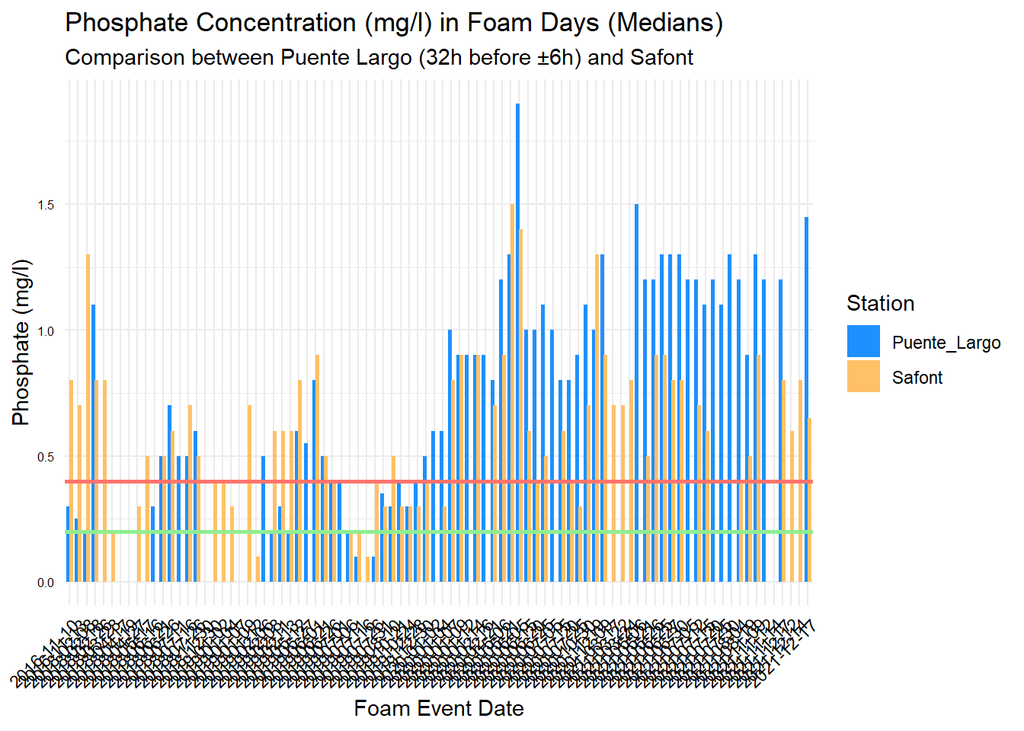

```r
# Puente Largo: keep only phosphates and date
puente_phosphate = daily_medians_puente %>%
  select(Foam_Event_Date, `Phosphates mg/l`) %>%
  rename(Puente_Largo = `Phosphates mg/l`)

# Safont: keep only phosphates and date
safont_phosphate = daily_medians %>%
  select(Event_Date, `Phosphates mg/l`) %>%
  rename(Safont = `Phosphates mg/l`,
         Foam_Event_Date = Event_Date)

# Merge them
phosphate_data = full_join(puente_phosphate, safont_phosphate, by = "Foam_Event_Date")

# Pivot longer for ggplot
phosphate_long = phosphate_data %>%
  pivot_longer(
    cols = c(Puente_Largo, Safont),
    names_to = "Station",
    values_to = "Phosphate_mg_l"
  )

limite_bueno_moderado <- .4
limite_muy_bueno_bueno <- 0.2

# Plot
ggplot(phosphate_long, aes(
  x = as.factor(Foam_Event_Date),
  y = Phosphate_mg_l,
  fill = Station
)) +
  geom_bar(stat = "identity", position = position_dodge(width = 0.7)) +
  geom_hline(yintercept = limite_bueno_moderado, color = "#FF746C", size = 1) +
  geom_hline(yintercept = limite_muy_bueno_bueno, color = "lightgreen", size = 1) +
  scale_fill_manual(values = c("Puente_Largo" = "#1E90FF", "Safont" = "#FFC067")) +
  labs(
    title = "Phosphate Concentration (mg/l) in Foam Days (Medians)",
    subtitle = "Comparison between Puente Largo (32h before ±6h) and Safont",
    x = "Foam Event Date",
    y = "Phosphate (mg/l)",
    fill = "Station"
  ) +
  theme_minimal() +
  theme(
    axis.text.x = element_text(angle = 45, hjust = 1, color = "black"),
    axis.text.y = element_text(size = 6, color = "black"),
    axis.title = element_text(color = "black"),
    plot.title = element_text(color = "black"),
    plot.background = element_rect(fill = "white", color = NA),
    panel.background = element_rect(fill = "white", color = NA),
    legend.background = element_rect(fill = "white", color = NA),
    legend.key = element_rect(fill = "white", color = NA),
    legend.text = element_text(color = "black"),
    legend.title = element_text(color = "black")
  )
```

```r
ggsave("phosphate_comparison_puentelargo_safont_medianas.png",  width = 20, height = 12, dpi = 300)
```

# Puente Largo contra Safont Grafica de Amonio

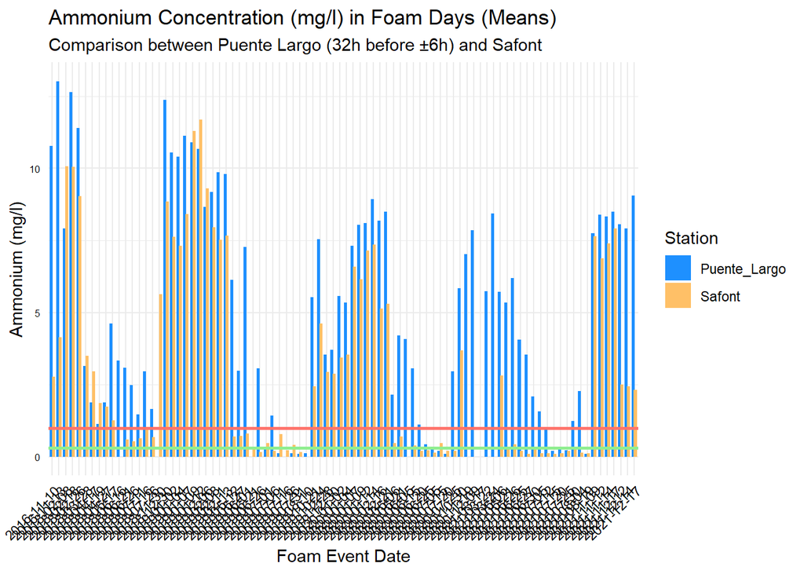

```r
# Puente Largo: keep only Ammonium and date
puente_ammonium = daily_means_puente %>%
  select(Foam_Event_Date, `Ammonium mg/l`) %>%
  rename(Puente_Largo = `Ammonium mg/l`)

# Safont: keep only Ammonium and date
safont_ammonium <- daily_means %>%
  select(Event_Date, `Ammonium mg/l`) %>%
  rename(Safont = `Ammonium mg/l`,
         Foam_Event_Date = Event_Date)

# Merge them
ammonium_data = full_join(puente_ammonium, safont_ammonium, by = "Foam_Event_Date")

# Pivot longer for ggplot
ammonium_long = ammonium_data %>%
  pivot_longer(
    cols = c(Puente_Largo, Safont),
    names_to = "Station",
    values_to = "Ammonium_mg_l"
  )

limite_bueno_moderado <- 1
limite_muy_bueno_bueno <- 0.3

# Plot
ggplot(ammonium_long, aes(
  x = as.factor(Foam_Event_Date),
  y = Ammonium_mg_l,
  fill = Station
)) +
  geom_bar(stat = "identity", position = position_dodge(width = 0.7)) +
  geom_hline(yintercept = limite_bueno_moderado, color = "#FF746C", size = 1) +
  geom_hline(yintercept = limite_muy_bueno_bueno, color = "lightgreen", size = 1) +
  scale_fill_manual(values = c("Puente_Largo" = "#1E90FF", "Safont" = "#FFC067")) +
  labs(
    title = "Ammonium Concentration (mg/l) in Foam Days (Means)",
    subtitle = "Comparison between Puente Largo (32h before ±6h) and Safont",
    x = "Foam Event Date",
    y = "Ammonium (mg/l)",
    fill = "Station"
  ) +
  theme_minimal() +
  theme(
    axis.text.x = element_text(angle = 45, hjust = 1, color = "black"),
    axis.text.y = element_text(size = 6, color = "black"),
    axis.title = element_text(color = "black"),
    plot.title = element_text(color = "black"),
    plot.background = element_rect(fill = "white", color = NA),
    panel.background = element_rect(fill = "white", color = NA),
    legend.background = element_rect(fill = "white", color = NA),
    legend.key = element_rect(fill = "white", color = NA),
    legend.text = element_text(color = "black"),
    legend.title = element_text(color = "black")
  )
```

```r
ggsave("ammonium_comparison_puentelargo_safont_medias.png",  width = 20, height = 12, dpi = 300)
```

# Puente Largo contra Safont grafica de fosfatos

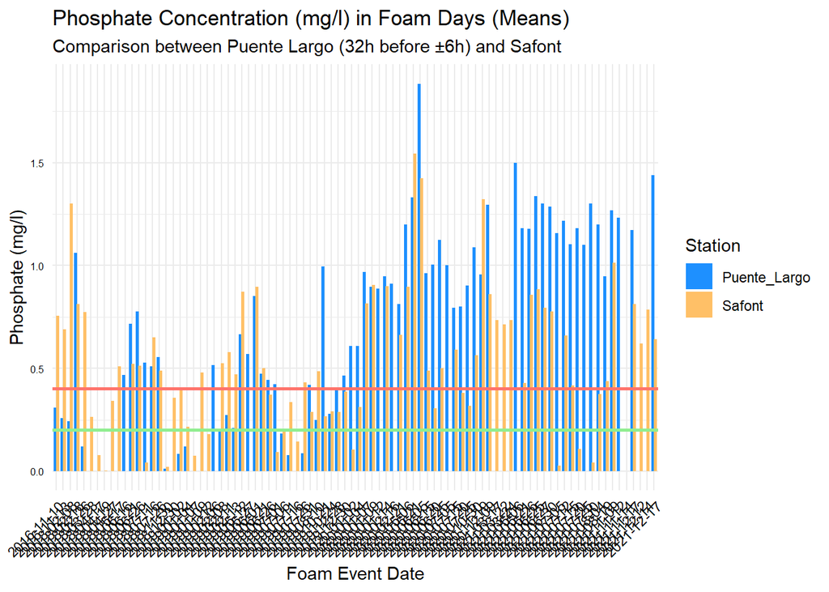

```r
# Puente Largo: keep only phosphates and date
puente_phosphate = daily_means_puente %>%
  select(Foam_Event_Date, `Phosphates mg/l`) %>%
  rename(Puente_Largo = `Phosphates mg/l`)

# Safont: keep only phosphates and date
safont_phosphate = daily_means %>%
  select(Event_Date, `Phosphates mg/l`) %>%
  rename(Safont = `Phosphates mg/l`,
         Foam_Event_Date = Event_Date)

# Merge them
phosphate_data = full_join(puente_phosphate, safont_phosphate, by = "Foam_Event_Date")

# Pivot longer for ggplot
phosphate_long = phosphate_data %>%
  pivot_longer(
    cols = c(Puente_Largo, Safont),
    names_to = "Station",
    values_to = "Phosphate_mg_l"
  )

limite_bueno_moderado <- .4
limite_muy_bueno_bueno <- 0.2

# Plot
ggplot(phosphate_long, aes(
  x = as.factor(Foam_Event_Date),
  y = Phosphate_mg_l,
  fill = Station
)) +
  geom_bar(stat = "identity", position = position_dodge(width = 0.7)) +
  geom_hline(yintercept = limite_bueno_moderado, color = "#FF746C", size = 1) +
  geom_hline(yintercept = limite_muy_bueno_bueno, color = "lightgreen", size = 1) +
  scale_fill_manual(values = c("Puente_Largo" = "#1E90FF", "Safont" = "#FFC067")) +
  labs(
    title = "Phosphate Concentration (mg/l) in Foam Days (Means)",
    subtitle = "Comparison between Puente Largo (32h before ±6h) and Safont",
    x = "Foam Event Date",
    y = "Phosphate (mg/l)",
    fill = "Station"
  ) +
  theme_minimal() +
  theme(
    axis.text.x = element_text(angle = 45, hjust = 1, color = "black"),
    axis.text.y = element_text(size = 6, color = "black"),
    axis.title = element_text(color = "black"),
    plot.title = element_text(color = "black"),
    plot.background = element_rect(fill = "white", color = NA),
    panel.background = element_rect(fill = "white", color = NA),
    legend.background = element_rect(fill = "white", color = NA),
    legend.key = element_rect(fill = "white", color = NA),
    legend.text = element_text(color = "black"),
    legend.title = element_text(color = "black")
  )
```

```r
ggsave("phosphate_comparison_puentelargo_safont_medias.png",  width = 20, height = 12, dpi = 300)
```